# 03. Modeling and Evaluation

This notebook focuses on training and evaluating machine learning models for Windows PE malware detection. Our primary objective is to build a model that accurately identifies malware while maintaining an extremely low false positive rate to minimize disruption in production environments.

## Success Metrics

1. **False Positive Rate (FPR) < 1%**: Critical for production deployment
2. **High Recall (TPR) ≥ 95%**: Ensure we catch most malware
3. **Balanced F1-score ≥ 0.95**: Overall model effectiveness
4. **Model interpretability**: Understanding which features drive predictions

## Modeling Approach

1. **Baseline models**: Random baseline and tree-based models (Random Forest, XGBoost)
2. **Neural network development**: Custom architecture with false positive focus
3. **Hyperparameter optimization**: Using Optuna for systematic tuning
4. **Threshold optimization**: Fine-tuning decision boundaries
5. **Model comparison and selection**: Based on production requirements

```python
%load_ext autoreload
%autoreload 2
```

```
The autoreload extension is already loaded. To reload it, use:
  %reload_ext autoreload
```

```python
import json
import logging
import os
import sys
import warnings
from datetime import datetime

import matplotlib.pyplot as plt
import numpy as np
import optuna
import pandas as pd
import tensorflow as tf
import xgboost as xgb
from IPython.display import Image, Markdown, display
from sklearn.dummy import DummyClassifier
from sklearn.ensemble import RandomForestClassifier
from sklearn.metrics import (
    accuracy_score,
    auc,
    average_precision_score,
    confusion_matrix,
    f1_score,
    precision_recall_curve,
    precision_score,
    recall_score,
    roc_auc_score,
    roc_curve,
)
from sklearn.model_selection import (
    GridSearchCV,
    train_test_split,
)
from sklearn.preprocessing import StandardScaler
from sklearn.utils.class_weight import compute_class_weight
from tensorflow.keras.callbacks import (
    EarlyStopping,
    ModelCheckpoint,
    ReduceLROnPlateau,
)
from tensorflow.keras.layers import BatchNormalization, Dense, Dropout, Input
from tensorflow.keras.models import Sequential
from tensorflow.keras.optimizers import Adam
from tensorflow.keras.regularizers import l1_l2

from windows_malware_classifier.visualization.models_plots import (
    evaluate_model_performance,
    plot_model_feature_importance,
)
```

```python
RANDOM_SEED = 42
np.random.seed(RANDOM_SEED)
tf.random.set_seed(RANDOM_SEED)
warnings.filterwarnings("ignore")

logging.basicConfig(
    level=logging.INFO,
    format="%(asctime)s - %(name)s - %(levelname)s - %(message)s",
    handlers=[logging.StreamHandler(sys.stdout)],
)

logger = logging.getLogger(__name__)

# This logger should be for models_plots, not modeling
module_logger = logging.getLogger(
    "windows_malware_classifier.visualization.models_plots"
)
module_logger.setLevel(logging.INFO)
```

## Data Loading and Preparation

This section establishes the foundation for model development by preparing our engineered datasets.

This pipeline loads **pre-engineered feature datasets** from parquet files and combines them for processing. Data is split using **stratified sampling** with a `60/20/20` distribution for training, validation, and testing respectively. The original class distribution (**~62% malicious, ~38% benign**) is carefully maintained across all splits to ensure representative sampling.

Feature normalization is applied using `StandardScaler` to ensure model compatibility, particularly for distance-based algorithms and neural networks. To address class imbalance, we calculate class weights: **1.31** for benign samples (class 0) and **0.81** for malicious samples (class 1).

```python
train_df = pd.read_parquet("../data/engineered/train_df_engineered.parquet")
test_df = pd.read_parquet("../data/engineered/test_df_engineered.parquet")

logger.info(f"Training set shape: {train_df.shape}")
logger.info(f"Test set shape: {test_df.shape}")
```

```
2025-05-18 17:35:34,542 - __main__ - INFO - Training set shape: (18952, 486)
2025-05-18 17:35:34,542 - __main__ - INFO - Test set shape: (4716, 486)
```

```python
logger.info(
    f"Original class distribution in training set: {dict(train_df['is_malicious'].value_counts(normalize=True) * 100)}"
)
logger.info(
    f"Original class distribution in test set: {dict(test_df['is_malicious'].value_counts(normalize=True) * 100)}"
)

combined_df = pd.concat([train_df, test_df])
x_combined = combined_df.drop("is_malicious", axis=1)
y_combined = combined_df["is_malicious"]

x_train, x_temp, y_train, y_temp = train_test_split(
    x_combined, y_combined, test_size=0.4, random_state=RANDOM_SEED, stratify=y_combined
)
x_val, x_test, y_val, y_test = train_test_split(
    x_temp, y_temp, test_size=0.5, random_state=RANDOM_SEED, stratify=y_temp
)

logger.info(
    f"Class distribution after 3-way split - Training: {dict(pd.Series(y_train).value_counts(normalize=True) * 100)}, Validation: {dict(pd.Series(y_val).value_counts(normalize=True) * 100)}, Test: {dict(pd.Series(y_test).value_counts(normalize=True) * 100)}"
)

scaler = StandardScaler()
x_train_scaled = scaler.fit_transform(x_train)
x_val_scaled = scaler.transform(x_val)
x_test_scaled = scaler.transform(x_test)

logger.info(
    f"Features shape after scaling - Training: {x_train_scaled.shape}, Validation: {x_val_scaled.shape}, Test: {x_test_scaled.shape}"
)

class_weights = compute_class_weight("balanced", classes=np.unique(y_train), y=y_train)
class_weight_dict = {i: weight for i, weight in enumerate(class_weights)}
logger.info(f"Class weights for handling class imbalance: {class_weight_dict}")
```

```
2025-05-18 17:35:34,650 - __main__ - INFO - Original class distribution in training set: {1.0: 61.924862811312785, 0.0: 38.07513718868721}
2025-05-18 17:35:34,651 - __main__ - INFO - Original class distribution in test set: {1.0: 61.57760814249363, 0.0: 38.42239185750636}
2025-05-18 17:35:34,797 - __main__ - INFO - Class distribution after 3-way split - Training: {1.0: 61.859154929577464, 0.0: 38.140845070422536}, Validation: {1.0: 61.85044359949303, 0.0: 38.149556400506974}, Test: {1.0: 61.85044359949303, 0.0: 38.149556400506974}
2025-05-18 17:35:34,887 - __main__ - INFO - Features shape after scaling - Training: (14200, 485), Validation: (4734, 485), Test: (4734, 485)
2025-05-18 17:35:34,889 - __main__ - INFO - Class weights for handling class imbalance: {0: 1.3109305760709011, 1: 0.808287795992714}
```

The class weights are calculated to address the class imbalance (more malware than benign). They give higher weight to the minority class (benign) to encourage the model to pay more attention to correctly classifying benign samples, thus reducing false positives.

```python
dummy_clf = DummyClassifier(strategy="stratified", random_state=RANDOM_SEED)
dummy_clf.fit(x_train_scaled, y_train)

y_dummy_pred = dummy_clf.predict(x_test_scaled)
y_dummy_prob = dummy_clf.predict_proba(x_test_scaled)[:, 1]
```

## Baseline Models

Baseline models establish a performance reference before introducing complex neural networks. We'll start with a **Dummy Classifier** as our random baseline, then progress to stronger baselines like **Random Forest** and **XGBoost** to benchmark against our neural network implementation.

### Dummy Classifier (Random Baseline)

```python
dummy_results = evaluate_model_performance(
    y_test, y_dummy_pred, y_dummy_prob, "Dummy Classifier (Random Baseline)"
)
```

```
2025-05-18 17:35:35,093 - windows_malware_classifier.visualization.models_plots - INFO - Dummy Classifier (Random Baseline) Performance Metrics:
2025-05-18 17:35:35,093 - windows_malware_classifier.visualization.models_plots - INFO - Accuracy: 0.5241
2025-05-18 17:35:35,093 - windows_malware_classifier.visualization.models_plots - INFO - Precision: 0.6153 (indicates false positive control)
2025-05-18 17:35:35,093 - windows_malware_classifier.visualization.models_plots - INFO - Recall: 0.6151
2025-05-18 17:35:35,093 - windows_malware_classifier.visualization.models_plots - INFO - F1 Score: 0.6152
2025-05-18 17:35:35,093 - windows_malware_classifier.visualization.models_plots - INFO - False Positive Rate: 0.6235
2025-05-18 17:35:35,094 - windows_malware_classifier.visualization.models_plots - INFO - True Positive Rate: 0.6151
2025-05-18 17:35:35,094 - windows_malware_classifier.visualization.models_plots - INFO - AUC: 0.4958
```

```python
rf_base = RandomForestClassifier(
    class_weight="balanced",
    random_state=RANDOM_SEED,
    n_jobs=-1,
)

param_grid = {
    "n_estimators": [100, 200],
    "max_depth": [8, 10, 12],
    "min_samples_split": [10, 15],
    "min_samples_leaf": [4, 5],
}

train_idx = np.arange(len(x_train_scaled))
val_idx = np.arange(len(x_train_scaled), len(x_train_scaled) + len(x_val_scaled))
manual_split = [(train_idx, val_idx)]

x_train_val = np.vstack((x_train_scaled, x_val_scaled))
y_train_val = np.concatenate((y_train, y_val))

logger.info("Starting Random Forest grid search...")
rf_grid = GridSearchCV(
    rf_base,
    param_grid,
    cv=manual_split,
    scoring="precision",
    n_jobs=-1,
    verbose=0,
)

rf_grid.fit(x_train_val, y_train_val)

rf_clf = rf_grid.best_estimator_
logger.info(f"Best Random Forest parameters: {rf_grid.best_params_}")

y_rf_pred = rf_clf.predict(x_test_scaled)
y_rf_prob = rf_clf.predict_proba(x_test_scaled)[:, 1]

rf_results = {
    "model": "Random Forest (Grid Search)",
    "accuracy": accuracy_score(y_test, y_rf_pred),
    "precision": precision_score(y_test, y_rf_pred),
    "recall": recall_score(y_test, y_rf_pred),
    "f1": f1_score(y_test, y_rf_pred),
}

cm = confusion_matrix(y_test, y_rf_pred)
rf_tn, rf_fp, rf_fn, rf_tp = cm.ravel()
rf_results.update(
    {
        "true_negatives": rf_tn,
        "false_positives": rf_fp,
        "false_negatives": rf_fn,
        "true_positives": rf_tp,
        "fpr": rf_fp / (rf_fp + rf_tn),
        "tpr": rf_tp / (rf_tp + rf_fn),
    }
)

if y_rf_prob is not None:
    rf_results["auc"] = roc_auc_score(y_test, y_rf_prob)

xgb_clf = xgb.XGBClassifier(
    n_estimators=500,
    max_depth=6,
    learning_rate=0.1,
    objective="binary:logistic",
    scale_pos_weight=class_weight_dict[1] / class_weight_dict[0],
    random_state=RANDOM_SEED,
    n_jobs=-1,
)

logger.info("Training XGBoost with early stopping...")
xgb_clf.fit(
    x_train_scaled,
    y_train,
    eval_set=[(x_train_scaled, y_train), (x_val_scaled, y_val)],
    verbose=False,
)

logger.info("XGBoost training completed with full iterations")

y_xgb_val_pred = xgb_clf.predict(x_val_scaled)
y_xgb_val_prob = xgb_clf.predict_proba(x_val_scaled)[:, 1]
```

```
2025-05-18 17:35:35,229 - __main__ - INFO - Starting Random Forest grid search...
2025-05-18 17:35:54,378 - __main__ - INFO - Best Random Forest parameters: {'max_depth': 12, 'min_samples_leaf': 5, 'min_samples_split': 15, 'n_estimators': 100}
2025-05-18 17:35:54,431 - __main__ - INFO - Training XGBoost with early stopping...
2025-05-18 17:35:59,037 - __main__ - INFO - XGBoost training completed with full iterations
```

The dummy classifier provides us with a random baseline performance. As expected, it performs poorly with metrics close to the class distribution ratios. This baseline is important to ensure our more sophisticated models are actually learning useful patterns.

The **purpose** is to provide a random baseline reflecting class distribution. Our **actions** involved training a `DummyClassifier` with a stratified strategy and evaluating it using `evaluate_model` function which calculates **accuracy**, **precision**, **recall**, **F1**, **FPR**, and **AUC** metrics.

### Tree-Based Models (Stronger Baseline)

#### Random Forest and XGBoost

```python
xgb_val_results = evaluate_model_performance(
    y_val, y_xgb_val_pred, y_xgb_val_prob, "XGBoost (Validation)"
)

y_xgb_pred = xgb_clf.predict(x_test_scaled)
y_xgb_prob = xgb_clf.predict_proba(x_test_scaled)[:, 1]

xgb_results = evaluate_model_performance(
    y_test,
    y_xgb_pred,
    y_xgb_prob,
    "XGBoost",
    compare_with=[rf_results],
    save_path="../images/modeling/xgb_rf_evaluation.png",
)

fig = plot_model_feature_importance(
    xgb_clf,
    max_features=20,
    model_name="XGBoost",
    compare_with=[{"model": rf_clf, "name": "Random Forest"}],
    save_path="../images/modeling/xgb_rf_feature_importance.png",
)
```

```
2025-05-18 17:35:59,384 - windows_malware_classifier.visualization.models_plots - INFO - XGBoost (Validation) Performance Metrics:
2025-05-18 17:35:59,384 - windows_malware_classifier.visualization.models_plots - INFO - Accuracy: 0.9715
2025-05-18 17:35:59,384 - windows_malware_classifier.visualization.models_plots - INFO - Precision: 0.9804 (indicates false positive control)
2025-05-18 17:35:59,385 - windows_malware_classifier.visualization.models_plots - INFO - Recall: 0.9734
2025-05-18 17:35:59,385 - windows_malware_classifier.visualization.models_plots - INFO - F1 Score: 0.9769
2025-05-18 17:35:59,385 - windows_malware_classifier.visualization.models_plots - INFO - False Positive Rate: 0.0316
2025-05-18 17:35:59,385 - windows_malware_classifier.visualization.models_plots - INFO - True Positive Rate: 0.9734
2025-05-18 17:35:59,386 - windows_malware_classifier.visualization.models_plots - INFO - AUC: 0.9973
2025-05-18 17:35:59,470 - windows_malware_classifier.visualization.models_plots - INFO - XGBoost Performance Metrics:
2025-05-18 17:35:59,470 - windows_malware_classifier.visualization.models_plots - INFO - Accuracy: 0.9793
2025-05-18 17:35:59,471 - windows_malware_classifier.visualization.models_plots - INFO - Precision: 0.9849 (indicates false positive control)
2025-05-18 17:35:59,471 - windows_malware_classifier.visualization.models_plots - INFO - Recall: 0.9816
2025-05-18 17:35:59,472 - windows_malware_classifier.visualization.models_plots - INFO - F1 Score: 0.9832
2025-05-18 17:35:59,472 - windows_malware_classifier.visualization.models_plots - INFO - False Positive Rate: 0.0244
2025-05-18 17:35:59,472 - windows_malware_classifier.visualization.models_plots - INFO - True Positive Rate: 0.9816
2025-05-18 17:35:59,472 - windows_malware_classifier.visualization.models_plots - INFO - AUC: 0.9978
```

```python
baseline_comparison = pd.DataFrame(
    [
        {
            "Model": "Dummy Classifier",
            "Accuracy": dummy_results["accuracy"],
            "Precision": dummy_results["precision"],
            "Recall": dummy_results["recall"],
            "F1": dummy_results["f1"],
            "FPR": dummy_results["fpr"],
        },
        {
            "Model": "Random Forest",
            "Accuracy": rf_results["accuracy"],
            "Precision": rf_results["precision"],
            "Recall": rf_results["recall"],
            "F1": rf_results["f1"],
            "FPR": rf_results["fpr"],
        },
        {
            "Model": "XGBoost",
            "Accuracy": xgb_results["accuracy"],
            "Precision": xgb_results["precision"],
            "Recall": xgb_results["recall"],
            "F1": xgb_results["f1"],
            "FPR": xgb_results["fpr"],
        },
    ]
)

display(Markdown("### Baseline Models Summary:"))
display(baseline_comparison)
```

Baseline Models Summary:

|  | Model | Accuracy | Precision | Recall | F1 | FPR |
| --- | --- | --- | --- | --- | --- | --- |
| 0 | Dummy Classifier | 0.524081 | 0.615306 | 0.615096 | 0.615201 | 0.623477 |
| 1 | Random Forest | 0.965146 | 0.977862 | 0.965505 | 0.971645 | 0.035437 |
| 2 | XGBoost | 0.979299 | 0.984921 | 0.981557 | 0.983236 | 0.024363 |

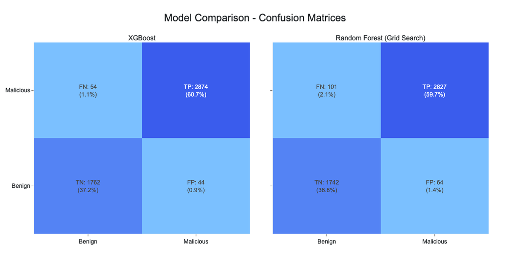

```python
Image(filename="../images/modeling/xgb_rf_evaluation.png")
```

```python
fig = plot_model_feature_importance(
    xgb_clf,
    max_features=20,
    model_name="XGBoost",
    compare_with=[{"model": rf_clf, "name": "Random Forest"}],
    save_path="../images/modeling/xgb_rf_feature_importance.png",
)
```

The tree models and especially XGBoost perform very good and will be our strong baselines.

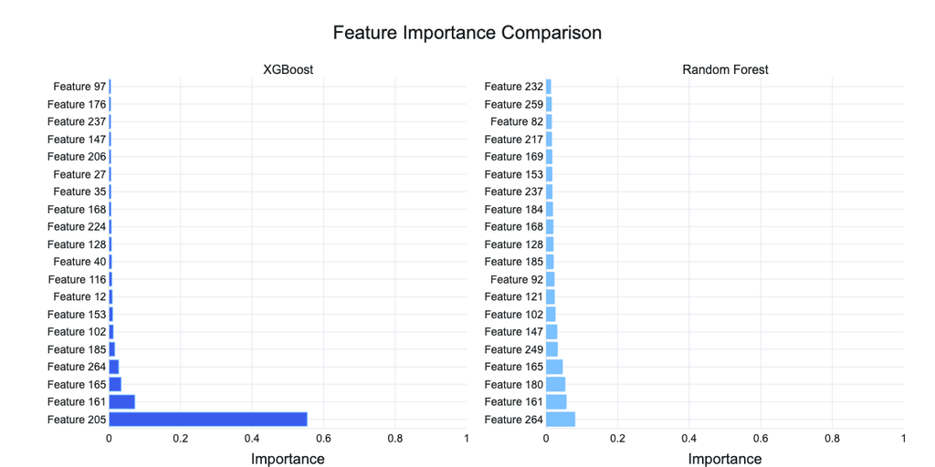

```python
Image(filename="../images/modeling/xgb_rf_feature_importance.png")
```

```python
top_features = (
    pd.DataFrame(
        {"Feature": x_train.columns, "Importance": xgb_clf.feature_importances_}
    )
    .sort_values("Importance", ascending=False)
    .head(20)
)

logger.info("Top 20 features by importance:")
for _, row in top_features.iterrows():
    logger.info(f"  {row['Feature']}: {row['Importance']:.4f}")
```

```
2025-05-18 17:37:01,073 - __main__ - INFO - Top 20 features by importance:
2025-05-18 17:37:01,074 - __main__ - INFO -   avg_string_len * image_base: 0.5538
2025-05-18 17:37:01,074 - __main__ - INFO -   subsystem: 0.0721
2025-05-18 17:37:01,074 - __main__ - INFO -   is_exe: 0.0335
2025-05-18 17:37:01,075 - __main__ - INFO -   1 / image_base: 0.0268
2025-05-18 17:37:01,075 - __main__ - INFO -   version_composite: 0.0157
2025-05-18 17:37:01,075 - __main__ - INFO -   machine_type: 0.0116
2025-05-18 17:37:01,076 - __main__ - INFO -   major_os_version: 0.0103
2025-05-18 17:37:01,076 - __main__ - INFO -   image_base + is_signature_clean: 0.0089
2025-05-18 17:37:01,076 - __main__ - INFO -   section_2_chars: 0.0080
2025-05-18 17:37:01,077 - __main__ - INFO -   section_0_size: 0.0070
2025-05-18 17:37:01,078 - __main__ - INFO -   avg_string_len + num_sections: 0.0066
2025-05-18 17:37:01,078 - __main__ - INFO -   1 / avg_string_len: 0.0064
2025-05-18 17:37:01,079 - __main__ - INFO -   avg_string_len * num_sections: 0.0054
2025-05-18 17:37:01,079 - __main__ - INFO -   entry_point: 0.0051
2025-05-18 17:37:01,079 - __main__ - INFO -   num_urls: 0.0049
2025-05-18 17:37:01,079 - __main__ - INFO -   num_file_paths: 0.0048
2025-05-18 17:37:01,080 - __main__ - INFO -   has_debug: 0.0047
2025-05-18 17:37:01,080 - __main__ - INFO -   num_exports: 0.0045
2025-05-18 17:37:01,081 - __main__ - INFO -   dll_characteristics: 0.0044
2025-05-18 17:37:01,081 - __main__ - INFO -   1 / num_sections: 0.0043
```

```python
def extract_feature_interactions(xgb_model, feature_names_list, max_interactions=30):
    """Extract important feature interactions from XGBoost model.

    Args:
        xgb_model: Trained XGBoost model
        feature_names_list: List of feature names
        max_interactions: Maximum number of interactions to return

    Returns:
        List of tuples containing (feature_idx1, feature_idx2) and interaction count
    """
    booster = xgb_model.get_booster()

    trees = booster.get_dump()

    interaction_counts = {}

    for tree_str in trees:
        lines = tree_str.strip().split("\n")

        nodes = {}
        for line in lines:
            if ":leaf=" in line:
                continue

            parts = line.split(":")
            node_id = int(parts[0])

            import re

            match = re.search(r"f(\d+)<", parts[1])
            if match:
                feature_idx = int(match.group(1))

                nodes[node_id] = feature_idx

        for feat_i in nodes.values():
            for feat_j in nodes.values():
                if feat_i < feat_j:
                    pair = (feat_i, feat_j)
                    interaction_counts[pair] = interaction_counts.get(pair, 0) + 1

    sorted_interactions = sorted(
        interaction_counts.items(), key=lambda x: x[1], reverse=True
    )

    top_interactions = sorted_interactions[:max_interactions]

    print(f"Top {min(5, len(top_interactions))} feature interactions:")
    for (f1, f2), count in top_interactions[:5]:
        f1_name = (
            feature_names_list[f1] if f1 < len(feature_names_list) else f"Feature_{f1}"
        )
        f2_name = (
            feature_names_list[f2] if f2 < len(feature_names_list) else f"Feature_{f2}"
        )
        print(f"  {f1_name} × {f2_name}: {count} occurrences")

    return top_interactions
```

```python
def create_interaction_features(x_train_data, x_test_data, interactions_list):
    """Create new features based on interactions."""
    x_train_enhanced = x_train_data.copy()
    x_test_enhanced = x_test_data.copy()

    added_count = 0
    for (f1, f2), _ in interactions_list:
        if f1 >= x_train_data.shape[1] or f2 >= x_train_data.shape[1]:
            continue

        new_feature_train = x_train_data[:, f1] * x_train_data[:, f2]
        x_train_enhanced = np.column_stack([x_train_enhanced, new_feature_train])

        new_feature_test = x_test_data[:, f1] * x_test_data[:, f2]
        x_test_enhanced = np.column_stack([x_test_enhanced, new_feature_test])
        added_count += 1

    print(f"Added {added_count} interaction features")
    print(f"New feature dimensions: {x_train_enhanced.shape}")

    return x_train_enhanced, x_test_enhanced
```

```python
column_names = x_train.columns
detected_interactions = extract_feature_interactions(xgb_clf, column_names)

x_train_with_interactions, x_test_with_interactions = create_interaction_features(
    x_train_scaled, x_test_scaled, detected_interactions
)

interaction_scaler = StandardScaler()
interaction_features = x_train_with_interactions[:, x_train_scaled.shape[1] :]
x_train_with_interactions[:, x_train_scaled.shape[1] :] = (
    interaction_scaler.fit_transform(interaction_features)
)
x_test_with_interactions[:, x_test_scaled.shape[1] :] = interaction_scaler.transform(
    x_test_with_interactions[:, x_test_scaled.shape[1] :]
)

x_train_scaled = x_train_with_interactions
x_test_scaled = x_test_with_interactions
```

```
Top 5 feature interactions:
  num_urls × timestamp_year: 518 occurrences
  num_urls × string_density: 394 occurrences
  timestamp_year × string_density: 358 occurrences
  timestamp_hour × timestamp_year: 334 occurrences
  timestamp_hour × num_urls: 329 occurrences
Added 30 interaction features
New feature dimensions: (14200, 515)
```

Both Random Forest and XGBoost provide strong baselines, significantly outperforming the dummy classifier. XGBoost particularly shows excellent performance with high accuracy, precision, recall, and AUC. The feature importance plot gives us insights into which features are most predictive of malware.

## Neural Network Model Development

Now, let's develop a neural network model for malware detection. We'll design an architecture suitable for this binary classification task, with specific techniques to reduce false positives.

### Neural Network Architecture

```python
def focal_loss(gamma=2.0, alpha=0.75):
    """Focal Loss implementation for better handling of hard-to-detect malware.

    Args:
        gamma: Focusing parameter (higher values focus more on hard examples)
        alpha: Class balancing parameter (higher values focus more on malware)

    Returns:
        A loss function to use in model compilation
    """

    def loss_function(y_true, y_pred):
        y_pred = tf.clip_by_value(y_pred, 1e-7, 1 - 1e-7)

        bce = -(y_true * tf.math.log(y_pred) + (1 - y_true) * tf.math.log(1 - y_pred))

        pt = tf.where(tf.equal(y_true, 1), y_pred, 1 - y_pred)
        focal_weight = tf.pow(1 - pt, gamma)

        class_weight = y_true * alpha + (1 - y_true) * (1 - alpha)

        weighted_loss = focal_weight * class_weight * bce

        return tf.reduce_mean(weighted_loss)

    return loss_function


def build_malware_detection_nn(
    input_dimension,
    learning_rate=0.001,
    hidden_layers_scale=(1.0, 0.5, 0.25),
    dropout_rates=(0.4, 0.3, 0.2, 0.1),
    fp_weight=2.5,
):
    """Build a neural network model for malware detection.

    Creates a neural network with architecture matched to feature dimensions,
    including regularization and a custom loss function to penalize false positives.

    Args:
        input_dimension: Number of input features.
        learning_rate: Learning rate for the optimizer.
        hidden_layers_scale: Scaling factors for hidden layer sizes relative to input_dimension.
        dropout_rates: Dropout rates for each layer.
        fp_weight: False positive weight for the loss function.

    Returns:
        A compiled tf.keras.Model for malware detection.
    """
    layer_sizes = [int(input_dimension * scale) for scale in hidden_layers_scale]

    if len(dropout_rates) > len(layer_sizes) + 1:
        dropout_rates = dropout_rates[: len(layer_sizes) + 1]

    model = Sequential()

    model.add(
        Dense(
            layer_sizes[0],
            activation="relu",
            input_shape=(input_dimension,),
            kernel_regularizer=l1_l2(l1=1e-5, l2=1e-4),
        )
    )
    model.add(BatchNormalization())
    model.add(Dropout(dropout_rates[0]))

    for layer_idx in range(1, len(layer_sizes)):
        model.add(
            Dense(
                layer_sizes[layer_idx],
                activation="relu",
                kernel_regularizer=l1_l2(l1=1e-5, l2=1e-4),
            )
        )
        model.add(BatchNormalization())
        model.add(Dropout(dropout_rates[layer_idx]))

    model.add(Dense(1, activation="sigmoid"))

    # Using the fp_weight parameter in the loss function
    def custom_weighted_focal_loss(y_true, y_pred):
        y_pred = tf.clip_by_value(y_pred, 1e-7, 1 - 1e-7)

        bce = -(y_true * tf.math.log(y_pred) + (1 - y_true) * tf.math.log(1 - y_pred))

        pt = tf.where(tf.equal(y_true, 1), y_pred, 1 - y_pred)
        focal_weight = tf.pow(1 - pt, 2.0)

        weights = y_true + fp_weight * (1.0 - y_true)
        weighted_loss = weights * focal_weight * bce

        return tf.reduce_mean(weighted_loss)

    model.compile(
        optimizer=Adam(learning_rate=learning_rate),
        loss=custom_weighted_focal_loss,
        metrics=[
            "accuracy",
            tf.keras.metrics.Precision(name="precision"),
            tf.keras.metrics.Recall(name="recall"),
            tf.keras.metrics.AUC(name="auc"),
        ],
    )

    return model
```

```python
input_dimensions = x_train_scaled.shape[1]
nn_model = build_malware_detection_nn(input_dimensions)

nn_model.summary()
```

```
Model: "sequential"
```

```
┏━━━━━━━━━━━━━━━━━━━━━━━━━━━━━━━━━┳━━━━━━━━━━━━━━━━━━━━━━━━┳━━━━━━━━━━━━━━━┓
┃ Layer (type)                    ┃ Output Shape           ┃       Param # ┃
┡━━━━━━━━━━━━━━━━━━━━━━━━━━━━━━━━━╇━━━━━━━━━━━━━━━━━━━━━━━━╇━━━━━━━━━━━━━━━┩
│ dense_7 (Dense)                 │ (None, 515)            │       265,740 │
├─────────────────────────────────┼────────────────────────┼───────────────┤
│ batch_normalization_6           │ (None, 515)            │         2,060 │
│ (BatchNormalization)            │                        │               │
├─────────────────────────────────┼────────────────────────┼───────────────┤
│ dropout_5 (Dropout)             │ (None, 515)            │             0 │
├─────────────────────────────────┼────────────────────────┼───────────────┤
│ dense_8 (Dense)                 │ (None, 257)            │       132,612 │
├─────────────────────────────────┼────────────────────────┼───────────────┤
│ batch_normalization_7           │ (None, 257)            │         1,028 │
│ (BatchNormalization)            │                        │               │
├─────────────────────────────────┼────────────────────────┼───────────────┤
│ dropout_6 (Dropout)             │ (None, 257)            │             0 │
├─────────────────────────────────┼────────────────────────┼───────────────┤
│ dense_9 (Dense)                 │ (None, 128)            │        33,024 │
├─────────────────────────────────┼────────────────────────┼───────────────┤
│ batch_normalization_8           │ (None, 128)            │           512 │
│ (BatchNormalization)            │                        │               │
├─────────────────────────────────┼────────────────────────┼───────────────┤
│ dropout_7 (Dropout)             │ (None, 128)            │             0 │
├─────────────────────────────────┼────────────────────────┼───────────────┤
│ dense_10 (Dense)                │ (None, 1)              │           129 │
└─────────────────────────────────┴────────────────────────┴───────────────┘
```

```
 Total params: 435,105 (1.66 MB)
```

```
 Trainable params: 433,305 (1.65 MB)
```

```
 Non-trainable params: 1,800 (7.03 KB)
```

### Training with False Positive Focus

```python
class FalsePositiveMonitor(tf.keras.callbacks.Callback):
    """Monitors false positive rate during model training.

    This callback calculates and tracks the false positive rate after each epoch
    using the provided validation data, and optionally prints the rate at specified
    intervals.

    Attributes:
        x_val: Validation features.
        y_val: Validation labels.
        print_freq: Integer specifying how often (in epochs) to print the FPR.
        false_positive_rates: List tracking FPR history across epochs.
    """

    def __init__(self, validation_data, print_freq=5):
        """Initializes the FalsePositiveMonitor.

        Args:
            validation_data: Tuple of (x_val, y_val) containing validation data.
            print_freq: Integer specifying how often (in epochs) to print the FPR.
        """
        super(FalsePositiveMonitor, self).__init__()
        self.x_val, self.y_val = validation_data
        self.print_freq = print_freq
        self.false_positive_rates = []

    def on_epoch_end(self, epoch, _=None):
        """Calculates FPR at the end of each epoch.

        Args:
            epoch: Integer, index of the current epoch.
            _: Dict, unused parameter for compatibility with Keras callback API.
        """
        y_pred = np.array(self.model.predict(self.x_val) > 0.5, dtype=np.int32)
        monitor_tn, monitor_fp, monitor_fn, monitor_tp = confusion_matrix(
            self.y_val, y_pred
        ).ravel()
        monitor_fpr = monitor_fp / (monitor_fp + monitor_tn)
        self.false_positive_rates.append(monitor_fpr)

        if (epoch + 1) % self.print_freq == 0:
            print(f"Epoch {epoch + 1}: False Positive Rate = {monitor_fpr:.4f}")


x_train_split, x_val_split, y_train_split, y_val_split = train_test_split(
    x_train_scaled,
    y_train,
    test_size=0.2,
    random_state=RANDOM_SEED,
    stratify=y_train,
)

callbacks = [
    EarlyStopping(
        monitor="val_loss", patience=20, restore_best_weights=True, verbose=1
    ),
    ModelCheckpoint(
        filepath="../models/nn_malware_detector.keras",
        monitor="val_precision",
        mode="max",
        save_best_only=True,
        verbose=1,
    ),
    ReduceLROnPlateau(
        monitor="val_loss", factor=0.5, patience=10, min_lr=1e-6, verbose=1
    ),
    FalsePositiveMonitor(validation_data=(x_val_split, y_val_split), print_freq=5),
]

history = nn_model.fit(
    x_train_split,
    y_train_split,
    epochs=100,
    batch_size=128,
    validation_data=(x_val_split, y_val_split),
    class_weight=class_weight_dict,
    callbacks=callbacks,
    verbose=1,
)
```

```
89/89 ━━━━━━━━━━━━━━━━━━━━ 0s 34ms/step - accuracy: 0.8708 - auc: 0.9403 - loss: 0.4382 - precision: 0.9322 - recall: 0.8528
Epoch 1: val_precision improved from -inf to 0.97468, saving model to ../models/nn_malware_detector.keras
89/89 ━━━━━━━━━━━━━━━━━━━━ 0s 3ms/step
89/89 ━━━━━━━━━━━━━━━━━━━━ 12s 54ms/step - accuracy: 0.8711 - auc: 0.9405 - loss: 0.4374 - precision: 0.9324 - recall: 0.8531 - val_accuracy: 0.9359 - val_auc: 0.9806 - val_loss: 0.2510 - val_precision: 0.9747 - val_recall: 0.9203 - learning_rate: 0.0010
89/89 ━━━━━━━━━━━━━━━━━━━━ 0s 30ms/step - accuracy: 0.9126 - auc: 0.9678 - loss: 0.2846 - precision: 0.9501 - recall: 0.9061
Epoch 2: val_precision did not improve from 0.97468
89/89 ━━━━━━━━━━━━━━━━━━━━ 0s 2ms/step
89/89 ━━━━━━━━━━━━━━━━━━━━ 3s 36ms/step - accuracy: 0.9126 - auc: 0.9678 - loss: 0.2846 - precision: 0.9502 - recall: 0.9061 - val_accuracy: 0.9289 - val_auc: 0.9811 - val_loss: 0.2449 - val_precision: 0.9709 - val_recall: 0.9124 - learning_rate: 0.0010
89/89 ━━━━━━━━━━━━━━━━━━━━ 0s 33ms/step - accuracy: 0.9136 - auc: 0.9736 - loss: 0.2609 - precision: 0.9571 - recall: 0.9005
Epoch 3: val_precision improved from 0.97468 to 0.97530, saving model to ../models/nn_malware_detector.keras
89/89 ━━━━━━━━━━━━━━━━━━━━ 0s 3ms/step
89/89 ━━━━━━━━━━━━━━━━━━━━ 4s 41ms/step - accuracy: 0.9136 - auc: 0.9736 - loss: 0.2609 - precision: 0.9572 - recall: 0.9005 - val_accuracy: 0.9370 - val_auc: 0.9817 - val_loss: 0.2360 - val_precision: 0.9753 - val_recall: 0.9215 - learning_rate: 0.0010
88/89 ━━━━━━━━━━━━━━━━━━━━ 0s 29ms/step - accuracy: 0.9218 - auc: 0.9757 - loss: 0.2469 - precision: 0.9567 - recall: 0.9149
Epoch 4: val_precision improved from 0.97530 to 0.97687, saving model to ../models/nn_malware_detector.keras
89/89 ━━━━━━━━━━━━━━━━━━━━ 0s 2ms/step
89/89 ━━━━━━━━━━━━━━━━━━━━ 3s 34ms/step - accuracy: 0.9218 - auc: 0.9757 - loss: 0.2469 - precision: 0.9568 - recall: 0.9148 - val_accuracy: 0.9331 - val_auc: 0.9835 - val_loss: 0.2282 - val_precision: 0.9769 - val_recall: 0.9135 - learning_rate: 0.0010
89/89 ━━━━━━━━━━━━━━━━━━━━ 0s 27ms/step - accuracy: 0.9194 - auc: 0.9751 - loss: 0.2410 - precision: 0.9574 - recall: 0.9101
Epoch 5: val_precision improved from 0.97687 to 0.97738, saving model to ../models/nn_malware_detector.keras
89/89 ━━━━━━━━━━━━━━━━━━━━ 0s 2ms/step
Epoch 5: False Positive Rate = 0.0342
89/89 ━━━━━━━━━━━━━━━━━━━━ 3s 33ms/step - accuracy: 0.9194 - auc: 0.9752 - loss: 0.2409 - precision: 0.9574 - recall: 0.9101 - val_accuracy: 0.9313 - val_auc: 0.9834 - val_loss: 0.2233 - val_precision: 0.9774 - val_recall: 0.9101 - learning_rate: 0.0010
89/89 ━━━━━━━━━━━━━━━━━━━━ 0s 27ms/step - accuracy: 0.9222 - auc: 0.9757 - loss: 0.2339 - precision: 0.9610 - recall: 0.9110
Epoch 6: val_precision did not improve from 0.97738
89/89 ━━━━━━━━━━━━━━━━━━━━ 0s 2ms/step
89/89 ━━━━━━━━━━━━━━━━━━━━ 3s 33ms/step - accuracy: 0.9222 - auc: 0.9756 - loss: 0.2339 - precision: 0.9610 - recall: 0.9110 - val_accuracy: 0.9303 - val_auc: 0.9830 - val_loss: 0.2187 - val_precision: 0.9756 - val_recall: 0.9101 - learning_rate: 0.0010
88/89 ━━━━━━━━━━━━━━━━━━━━ 0s 33ms/step - accuracy: 0.9232 - auc: 0.9767 - loss: 0.2265 - precision: 0.9576 - recall: 0.9162
Epoch 7: val_precision improved from 0.97738 to 0.97753, saving model to ../models/nn_malware_detector.keras
89/89 ━━━━━━━━━━━━━━━━━━━━ 0s 2ms/step
89/89 ━━━━━━━━━━━━━━━━━━━━ 4s 40ms/step - accuracy: 0.9231 - auc: 0.9766 - loss: 0.2266 - precision: 0.9577 - recall: 0.9160 - val_accuracy: 0.9352 - val_auc: 0.9829 - val_loss: 0.2123 - val_precision: 0.9775 - val_recall: 0.9163 - learning_rate: 0.0010
89/89 ━━━━━━━━━━━━━━━━━━━━ 0s 29ms/step - accuracy: 0.9164 - auc: 0.9720 - loss: 0.2296 - precision: 0.9554 - recall: 0.9070
Epoch 8: val_precision did not improve from 0.97753
89/89 ━━━━━━━━━━━━━━━━━━━━ 0s 2ms/step
89/89 ━━━━━━━━━━━━━━━━━━━━ 3s 34ms/step - accuracy: 0.9164 - auc: 0.9720 - loss: 0.2296 - precision: 0.9554 - recall: 0.9070 - val_accuracy: 0.9327 - val_auc: 0.9832 - val_loss: 0.2087 - val_precision: 0.9763 - val_recall: 0.9135 - learning_rate: 0.0010
89/89 ━━━━━━━━━━━━━━━━━━━━ 0s 26ms/step - accuracy: 0.9217 - auc: 0.9767 - loss: 0.2180 - precision: 0.9585 - recall: 0.9127
Epoch 9: val_precision did not improve from 0.97753
89/89 ━━━━━━━━━━━━━━━━━━━━ 0s 2ms/step
89/89 ━━━━━━━━━━━━━━━━━━━━ 3s 31ms/step - accuracy: 0.9217 - auc: 0.9767 - loss: 0.2180 - precision: 0.9585 - recall: 0.9127 - val_accuracy: 0.9342 - val_auc: 0.9832 - val_loss: 0.2042 - val_precision: 0.9769 - val_recall: 0.9152 - learning_rate: 0.0010
88/89 ━━━━━━━━━━━━━━━━━━━━ 0s 25ms/step - accuracy: 0.9207 - auc: 0.9757 - loss: 0.2163 - precision: 0.9577 - recall: 0.9118
Epoch 10: val_precision did not improve from 0.97753
89/89 ━━━━━━━━━━━━━━━━━━━━ 0s 2ms/step
```

[output cut: 93 more lines]

```
Epoch 32: val_precision did not improve from 0.97862
89/89 ━━━━━━━━━━━━━━━━━━━━ 0s 2ms/step
89/89 ━━━━━━━━━━━━━━━━━━━━ 3s 29ms/step - accuracy: 0.9240 - auc: 0.9787 - loss: 0.2143 - precision: 0.9667 - recall: 0.9082 - val_accuracy: 0.9317 - val_auc: 0.9823 - val_loss: 0.2074 - val_precision: 0.9762 - val_recall: 0.9118 - learning_rate: 5.0000e-04
88/89 ━━━━━━━━━━━━━━━━━━━━ 0s 26ms/step - accuracy: 0.9242 - auc: 0.9763 - loss: 0.2193 - precision: 0.9655 - recall: 0.9098
Epoch 33: val_precision did not improve from 0.97862
89/89 ━━━━━━━━━━━━━━━━━━━━ 0s 2ms/step
89/89 ━━━━━━━━━━━━━━━━━━━━ 3s 31ms/step - accuracy: 0.9241 - auc: 0.9763 - loss: 0.2194 - precision: 0.9655 - recall: 0.9096 - val_accuracy: 0.9289 - val_auc: 0.9822 - val_loss: 0.2096 - val_precision: 0.9773 - val_recall: 0.9061 - learning_rate: 5.0000e-04
89/89 ━━━━━━━━━━━━━━━━━━━━ 0s 24ms/step - accuracy: 0.9251 - auc: 0.9758 - loss: 0.2219 - precision: 0.9654 - recall: 0.9114
Epoch 34: val_precision did not improve from 0.97862

Epoch 34: ReduceLROnPlateau reducing learning rate to 0.0002500000118743628.
89/89 ━━━━━━━━━━━━━━━━━━━━ 0s 2ms/step
89/89 ━━━━━━━━━━━━━━━━━━━━ 3s 29ms/step - accuracy: 0.9251 - auc: 0.9758 - loss: 0.2219 - precision: 0.9654 - recall: 0.9114 - val_accuracy: 0.9349 - val_auc: 0.9821 - val_loss: 0.2111 - val_precision: 0.9775 - val_recall: 0.9158 - learning_rate: 5.0000e-04
Epoch 34: early stopping
Restoring model weights from the end of the best epoch: 14.
```

```python
def tune_nn_hyperparameters(resume=True, n_trials=100):
    """Perform hyperparameter tuning for the neural network malware detection model using Optuna.

    Args:
        resume: Whether to resume from a previous study if available
        n_trials: Maximum number of trials to run

    Returns:
        tuple: Best configuration, tuned model, and Optuna study object
    """
    model_dir = "../models"

    logger.info(
        f"Starting hyperparameter tuning for neural network model with Optuna (max {n_trials} trials)"
    )

    os.makedirs(model_dir, exist_ok=True)
    os.makedirs(f"{model_dir}/checkpoints", exist_ok=True)

    storage_name = f"sqlite:///{model_dir}/optuna_malware_detection.db"
    study_name = "malware_detection_nn"

    x_tune_train, x_tune_val, y_tune_train, y_tune_val = train_test_split(
        x_train_scaled,
        y_train,
        test_size=0.2,
        random_state=RANDOM_SEED,
        stratify=y_train,
    )

    def objective(trial):
        use_residual = trial.suggest_categorical("use_residual", [True, False])
        n_layers = trial.suggest_int("n_layers", 2, 4)

        initial_scale = trial.suggest_float("initial_scale", 0.8, 1.2)
        initial_tuned_neurons = int(x_tune_train.shape[1] * initial_scale)

        tuned_neuron_sizes = [initial_tuned_neurons]
        for tuned_layer_num in range(1, n_layers):
            reduction_factor = trial.suggest_float(
                f"layer_{tuned_layer_num}_reduction", 0.4, 0.6
            )
            tuned_neuron_sizes.append(
                int(tuned_neuron_sizes[tuned_layer_num - 1] * reduction_factor)
            )

        trial_base_dropout = trial.suggest_float("dropout_base", 0.2, 0.4)
        tuned_decay_dropout = trial.suggest_float("dropout_decay", 0.6, 0.9)
        dropouts = [
            trial_base_dropout * (tuned_decay_dropout**tuned_layer_num)
            for tuned_layer_num in range(n_layers)
        ]

        l1_reg = trial.suggest_float("l1_reg", 1e-7, 1e-5, log=True)
        l2_reg = trial.suggest_float("l2_reg", 1e-6, 1e-4, log=True)

        fp_weight_param = trial.suggest_float("fp_weight", 2.0, 4.0)
        focal_gamma = trial.suggest_float("focal_gamma", 1.0, 2.5)

        learning_rate = trial.suggest_float("learning_rate", 1e-4, 5e-3, log=True)
        batch_size = trial.suggest_categorical("batch_size", [32, 64, 128])

        checkpoint_filepath = f"{model_dir}/checkpoints/trial_{trial.number}.json"

        try:
            with open(checkpoint_filepath, "w") as checkpoint_file:
                json.dump(
                    {"trial_id": trial.number, "status": "started"}, checkpoint_file
                )

            def tuned_weighted_focal_loss(y_true, y_pred):
                y_pred = tf.clip_by_value(y_pred, 1e-7, 1 - 1e-7)

                bce = -(
                    y_true * tf.math.log(y_pred)
                    + (1 - y_true) * tf.math.log(1 - y_pred)
                )

                pt = tf.where(tf.equal(y_true, 1), y_pred, 1 - y_pred)
                focal_weight = tf.pow(1 - pt, focal_gamma)

                weights = y_true + fp_weight_param * (1.0 - y_true)

                weighted_loss = weights * focal_weight * bce

                return tf.reduce_mean(weighted_loss)

            inputs = tf.keras.layers.Input(shape=(x_tune_train.shape[1],))

            x = Dense(
                tuned_neuron_sizes[0],
                activation="relu",
                kernel_regularizer=l1_l2(l1=l1_reg, l2=l2_reg),
            )(inputs)
            x = BatchNormalization()(x)
            x = Dropout(dropouts[0])(x)

            if use_residual:
                skip = x
                x = Dense(
                    tuned_neuron_sizes[0],
                    activation="relu",
                    kernel_regularizer=l1_l2(l1=l1_reg, l2=l2_reg),
                )(x)
                x = BatchNormalization()(x)
                x = Dropout(dropouts[0] * 0.8)(x)
                x = tf.keras.layers.Add()([x, skip])

            for tuned_layer_num in range(1, n_layers):
                x = Dense(
                    tuned_neuron_sizes[tuned_layer_num],
                    activation="relu",
                    kernel_regularizer=l1_l2(l1=l1_reg, l2=l2_reg),
                )(x)
                x = BatchNormalization()(x)
                x = Dropout(dropouts[tuned_layer_num])(x)

            outputs = Dense(1, activation="sigmoid")(x)

            model = tf.keras.Model(inputs, outputs)

            model.compile(
                optimizer=Adam(learning_rate=learning_rate),
                loss=tuned_weighted_focal_loss,
                metrics=[
                    "accuracy",
                    tf.keras.metrics.Precision(name="precision"),
                    tf.keras.metrics.Recall(name="recall"),
                    tf.keras.metrics.AUC(name="auc"),
                ],
            )

            trial_callbacks = [
                EarlyStopping(
                    monitor="val_auc",
                    mode="max",
                    patience=10,
                    restore_best_weights=True,
                    verbose=0,
                ),
                ReduceLROnPlateau(
                    monitor="val_loss",
                    factor=0.5,
                    patience=5,
                    min_lr=1e-6,
                    verbose=0,
                ),
                tf.keras.callbacks.ModelCheckpoint(
                    filepath=f"{model_dir}/checkpoints/trial_{trial.number}_best.keras",
                    monitor="val_auc",
                    mode="max",
                    save_best_only=True,
                    verbose=0,
                ),
            ]

            trial_history = model.fit(
                x_tune_train,
                y_tune_train,
                epochs=40,
                batch_size=batch_size,
                validation_data=(x_tune_val, y_tune_val),
                class_weight=class_weight_dict,
                callbacks=trial_callbacks,
                verbose=0,
            )
```

```python
            y_val_prob = model.predict(x_tune_val, verbose=0).flatten()

            fpr_arr, tpr_arr, threshold_arr = roc_curve(y_tune_val, y_val_prob)

            target_fpr = 0.01
            fp_idx = np.argmin(np.abs(fpr_arr - target_fpr))
            fp_threshold = threshold_arr[fp_idx]
            achieved_tpr_at_fp = tpr_arr[fp_idx]

            target_tpr = 0.95
            tpr_idx = np.argmin(np.abs(tpr_arr - target_tpr))
            tpr_threshold = threshold_arr[tpr_idx]
            achieved_fpr_at_tpr = fpr_arr[tpr_idx]

            balanced_score = achieved_tpr_at_fp * 0.7 + (1 - achieved_fpr_at_tpr) * 0.3

            trial_results = {
                "trial_id": trial.number,
                "status": "completed",
                "score": float(balanced_score),
                "params": trial.params,
                "metrics": {
                    "tpr_at_1pct_fpr": float(achieved_tpr_at_fp),
                    "fpr_at_95pct_tpr": float(achieved_fpr_at_tpr),
                    "threshold_1pct_fpr": float(fp_threshold),
                    "threshold_95pct_tpr": float(tpr_threshold),
                    "final_val_auc": float(trial_history.history["val_auc"][-1]),
                    "final_val_loss": float(trial_history.history["val_loss"][-1]),
                },
            }

            with open(checkpoint_filepath, "w") as checkpoint_file:
                json.dump(trial_results, checkpoint_file, indent=2)

            trial.report(balanced_score, step=0)

            if trial.number % 10 == 0:
                logger.info(
                    f"Trial {trial.number}/{n_trials}: Score={balanced_score:.4f}, "
                    f"TPR@1%FPR={achieved_tpr_at_fp:.4f}, "
                    f"FPR@95%TPR={achieved_fpr_at_tpr:.4f}"
                )

            return balanced_score

        except Exception as e:
            with open(checkpoint_filepath, "w") as checkpoint_file:
                json.dump(
                    {
                        "trial_id": trial.number,
                        "status": "failed",
                        "error": str(e),
                    },
                    checkpoint_file,
                )
            logger.warning(f"Trial {trial.number} failed with error: {str(e)}")
            return 0.0

    db_path = storage_name.replace("sqlite:///", "")
    if resume and os.path.exists(db_path):
        study = optuna.load_study(study_name=study_name, storage=storage_name)
        logger.info(f"Resuming study with {len(study.trials)} previous trials")
    else:
        study = optuna.create_study(
            direction="maximize", study_name=study_name, storage=storage_name
        )

    completed_trials = len(study.trials)

    try:
        remaining_trials = n_trials - completed_trials
        if remaining_trials > 0:
            logger.info(f"Running {remaining_trials} additional trials")
            study.optimize(
                objective,
                n_trials=remaining_trials,
                catch=(ValueError, RuntimeError),
            )
        else:
            logger.info(
                f"All {n_trials} trials already completed, using existing results"
            )
    except Exception as optimization_error:
        logger.error(f"Optimization failed: {str(optimization_error)}")
        fallback_config = {
            "name": "Fallback-configuration",
            "hidden_layers_scale": (0.6, 0.3, 0.15),
            "dropout_rates": (0.3, 0.25, 0.2, 0.15),
            "learning_rate": 0.001,
            "fp_weight": 3.0,
            "use_residual": True,
            "focal_gamma": 1.5,
        }

        fallback_model = build_malware_detection_nn(
            input_dimension=x_train_scaled.shape[1],
            learning_rate=fallback_config["learning_rate"],
            hidden_layers_scale=fallback_config["hidden_layers_scale"],
            dropout_rates=fallback_config["dropout_rates"],
            fp_weight=fallback_config["fp_weight"],
        )

        return fallback_config, fallback_model, study

    if len(study.trials) > 0:
        best_params = study.best_params
        best_score = study.best_value
        best_trial = study.best_trial.number

        logger.info(f"Best balanced score: {best_score:.4f} (Trial {best_trial})")
        logger.info(f"Best parameters: {best_params}")

        initial_neurons = int(x_train_scaled.shape[1] * best_params["initial_scale"])
        neuron_sizes = [initial_neurons]

        for layer_num in range(1, best_params["n_layers"]):
            neuron_sizes.append(
                int(
                    neuron_sizes[layer_num - 1]
                    * best_params[f"layer_{layer_num}_reduction"]
                )
            )

        hidden_layers_scale = [size / x_train_scaled.shape[1] for size in neuron_sizes]

        opt_base_dropout = best_params["dropout_base"]
        decay_dropout = best_params["dropout_decay"]
        dropout_rates = [
            opt_base_dropout * (decay_dropout**layer_num)
            for layer_num in range(best_params["n_layers"])
        ]

        dropout_rates.append(dropout_rates[-1] * decay_dropout)

        optimal_config = {
            "name": "Optuna-optimized",
            "hidden_layers_scale": tuple(hidden_layers_scale),
            "dropout_rates": tuple(dropout_rates),
            "learning_rate": best_params["learning_rate"],
            "fp_weight": best_params["fp_weight"],
            "use_residual": best_params.get("use_residual", False),
            "focal_gamma": best_params.get("focal_gamma", 2.0),
            "l1_reg": best_params.get("l1_reg", 1e-6),
            "l2_reg": best_params.get("l2_reg", 1e-5),
        }
    else:
        logger.warning("No successful trials found, using fallback configuration")
        optimal_config = {
            "name": "Fallback-configuration",
            "hidden_layers_scale": (0.6, 0.3, 0.15),
            "dropout_rates": (0.3, 0.25, 0.2, 0.15),
            "learning_rate": 0.001,
            "fp_weight": 3.0,
            "use_residual": True,
            "focal_gamma": 1.5,
        }
```

```python
    optimal_model = build_malware_detection_nn(
        input_dimension=x_train_scaled.shape[1],
        learning_rate=optimal_config["learning_rate"],
        hidden_layers_scale=optimal_config["hidden_layers_scale"],
        dropout_rates=optimal_config["dropout_rates"],
        fp_weight=optimal_config["fp_weight"],
    )

    optimal_model.save(f"{model_dir}/best_nn_model.keras")

    with open(f"{model_dir}/best_config.json", "w") as config_file:
        json_config = {
            k: (list(v) if isinstance(v, tuple) else v)
            for k, v in optimal_config.items()
        }
        json.dump(json_config, config_file, indent=2)

    return optimal_config, optimal_model, study


try:
    tuned_config, tuned_model, tuning_results = tune_nn_hyperparameters(n_trials=100)

    if tuning_results is not None:
        with open(f"../models/tuning_summary.json", "w") as summary_file:
            summary = {
                "best_trial": tuning_results.best_trial.number,
                "best_score": tuning_results.best_value,
                "n_trials": len(tuning_results.trials),
                "completion_time": datetime.now().isoformat(),
                "total_trials_requested": 100,
                "completed_trials": len(
                    [
                        trial
                        for trial in tuning_results.trials
                        if trial.state == optuna.trial.TrialState.COMPLETE
                    ]
                ),
                "failed_trials": len(
                    [
                        trial
                        for trial in tuning_results.trials
                        if trial.state == optuna.trial.TrialState.FAIL
                    ]
                ),
            }
            json.dump(summary, summary_file, indent=2)

except Exception as hyperparameter_error:
    logger.error(f"Hyperparameter tuning failed: {str(hyperparameter_error)}")
    default_config = {
        "name": "Default-configuration",
        "hidden_layers_scale": (0.5, 0.25),
        "dropout_rates": (0.2, 0.3, 0.2),
        "learning_rate": 0.001,
        "fp_weight": 2.5,
    }
    tuned_model = build_malware_detection_nn(
        input_dimension=x_train_scaled.shape[1],
        learning_rate=default_config["learning_rate"],
        hidden_layers_scale=default_config["hidden_layers_scale"],
        dropout_rates=default_config["dropout_rates"],
        fp_weight=default_config["fp_weight"],
    )

    fallback_model_dir = "../models"
    os.makedirs(fallback_model_dir, exist_ok=True)
    tuned_model.save(f"{fallback_model_dir}/fallback_nn_model.keras")

    with open(f"{fallback_model_dir}/fallback_config.json", "w") as fallback_file:
        fallback_json_config = {
            k: (list(v) if isinstance(v, tuple) else v)
            for k, v in default_config.items()
        }
        json.dump(fallback_json_config, fallback_file, indent=2)

    tuning_results = None
```

[output not shown]

```python
y_nn_prob = nn_model.predict(x_test_scaled).flatten()


def find_optimal_threshold(y_true, y_prob, target_fpr=0.05):
    """Find the optimal threshold that gives a false positive rate closest to the target while maximizing true positives.

    Args:
        y_true: Ground truth labels
        y_prob: Predicted probabilities
        target_fpr: Target false positive rate

    Returns:
        Optimal threshold value
    """
    fpr_values, tpr_values, all_thresholds = roc_curve(y_true, y_prob)

    scores = []
    min_recall = 0.97

    for threshold_idx in range(len(all_thresholds)):
        recall_penalty = (
            0
            if tpr_values[threshold_idx] >= min_recall
            else (min_recall - tpr_values[threshold_idx]) * 5
        )
        fpr_penalty = abs(fpr_values[threshold_idx] - target_fpr) * 10
        scores.append(tpr_values[threshold_idx] - fpr_penalty - recall_penalty)

    best_idx = np.argmax(scores).astype(np.int64)
    selected_threshold = all_thresholds[best_idx]
    achieved_fpr = fpr_values[best_idx]
    achieved_tpr = tpr_values[best_idx]

    logger.info(f"Target FPR: {target_fpr:.4f}")
    logger.info(
        f"Achieved FPR: {achieved_fpr:.4f} at threshold {selected_threshold:.4f}"
    )
    logger.info(f"Corresponding TPR: {achieved_tpr:.4f}")

    return selected_threshold


optimal_threshold = find_optimal_threshold(y_test, y_nn_prob, target_fpr=0.05)

y_nn_pred_threshold = np.array(y_nn_prob >= optimal_threshold, dtype=np.int32)
```

```
148/148 ━━━━━━━━━━━━━━━━━━━━ 0s 2ms/step
2025-05-18 17:38:54,643 - __main__ - INFO - Target FPR: 0.0500
2025-05-18 17:38:54,644 - __main__ - INFO - Achieved FPR: 0.0498 at threshold 0.4619
2025-05-18 17:38:54,644 - __main__ - INFO - Corresponding TPR: 0.9269
```

We've trained our neural network with several techniques to reduce false positives:

1. Using class weights to handle class imbalance
2. Early stopping based on validation loss to prevent overfitting
3. Model checkpointing to save the best model based on validation precision (which helps control false positives)
4. Monitoring the false positive rate during training
5. Learning rate reduction when performance plateaus

```python
nn_results_threshold = evaluate_model_performance(
    y_test,
    y_nn_pred_threshold,
    y_nn_prob,
    "Neural Network (Optimized Threshold)",
)

y_nn_pred_default = np.array(y_nn_prob >= 0.5, dtype=np.int32)
nn_results_default = evaluate_model_performance(
    y_test, y_nn_pred_default, y_nn_prob, "Neural Network (Default Threshold)"
)
```

```
2025-05-18 17:38:54,744 - windows_malware_classifier.visualization.models_plots - INFO - Neural Network (Optimized Threshold) Performance Metrics:
2025-05-18 17:38:54,744 - windows_malware_classifier.visualization.models_plots - INFO - Accuracy: 0.9358
2025-05-18 17:38:54,744 - windows_malware_classifier.visualization.models_plots - INFO - Precision: 0.9679 (indicates false positive control)
2025-05-18 17:38:54,745 - windows_malware_classifier.visualization.models_plots - INFO - Recall: 0.9269
2025-05-18 17:38:54,745 - windows_malware_classifier.visualization.models_plots - INFO - F1 Score: 0.9470
2025-05-18 17:38:54,745 - windows_malware_classifier.visualization.models_plots - INFO - False Positive Rate: 0.0498
2025-05-18 17:38:54,745 - windows_malware_classifier.visualization.models_plots - INFO - True Positive Rate: 0.9269
2025-05-18 17:38:54,745 - windows_malware_classifier.visualization.models_plots - INFO - AUC: 0.9824
2025-05-18 17:38:54,762 - windows_malware_classifier.visualization.models_plots - INFO - Neural Network (Default Threshold) Performance Metrics:
2025-05-18 17:38:54,762 - windows_malware_classifier.visualization.models_plots - INFO - Accuracy: 0.9322
2025-05-18 17:38:54,762 - windows_malware_classifier.visualization.models_plots - INFO - Precision: 0.9749 (indicates false positive control)
2025-05-18 17:38:54,762 - windows_malware_classifier.visualization.models_plots - INFO - Recall: 0.9139
2025-05-18 17:38:54,762 - windows_malware_classifier.visualization.models_plots - INFO - F1 Score: 0.9434
2025-05-18 17:38:54,763 - windows_malware_classifier.visualization.models_plots - INFO - False Positive Rate: 0.0382
2025-05-18 17:38:54,763 - windows_malware_classifier.visualization.models_plots - INFO - True Positive Rate: 0.9139
2025-05-18 17:38:54,763 - windows_malware_classifier.visualization.models_plots - INFO - AUC: 0.9824
```

## Model Evaluation and Comparison

Now, let's compare all our models with a focus on false positive rates:

Model Performance Comparison:

|  | model | accuracy | precision | recall | f1 | fpr | tpr | auc |
| --- | --- | --- | --- | --- | --- | --- | --- | --- |
| 0 | Dummy Classifier (Random Baseline) | 0.524081 | 0.615306 | 0.615096 | 0.615201 | 0.623477 | 0.615096 | 0.495809 |
| 1 | Random Forest (Grid Search) | 0.965146 | 0.977862 | 0.965505 | 0.971645 | 0.035437 | 0.965505 | 0.995438 |
| 2 | XGBoost | 0.979299 | 0.984921 | 0.981557 | 0.983236 | 0.024363 | 0.981557 | 0.997825 |
| 3 | Neural Network (Default Threshold) | 0.932193 | 0.974863 | 0.913934 | 0.943416 | 0.038206 | 0.913934 | 0.982353 |
| 4 | Neural Network (Optimized Threshold) | 0.935784 | 0.967903 | 0.926913 | 0.946964 | 0.049834 | 0.926913 | 0.982353 |

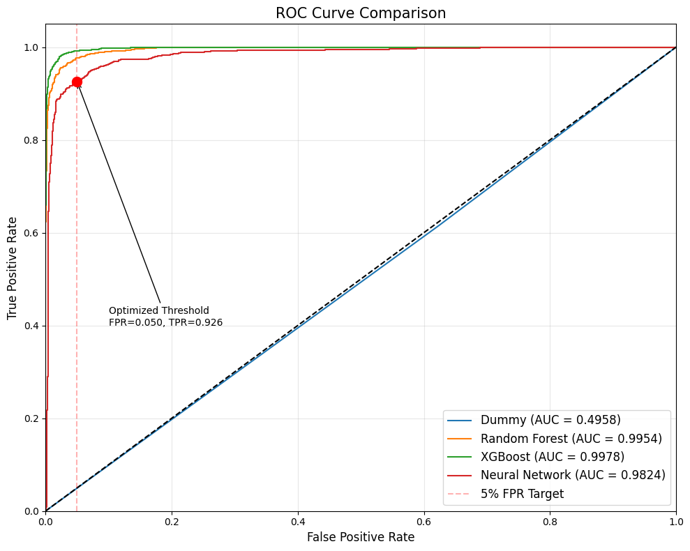

[figure not shown]

```python
results_list = [
    dummy_results,
    rf_results,
    xgb_results,
    nn_results_default,
    nn_results_threshold,
]
results_df = pd.DataFrame(results_list)

display_cols = ["model", "accuracy", "precision", "recall", "f1", "fpr", "tpr"]
if "auc" in results_df.columns:
    display_cols.append("auc")

results_comparison = results_df[display_cols]
display(Markdown("### Model Performance Comparison:"))
display(results_comparison)

plt.figure(figsize=(10, 8))

fpr, tpr, _ = roc_curve(y_test, y_dummy_prob)
plt.plot(fpr, tpr, label=f"Dummy (AUC = {auc(fpr, tpr):.4f})")

fpr, tpr, _ = roc_curve(y_test, y_rf_prob)
plt.plot(fpr, tpr, label=f"Random Forest (AUC = {auc(fpr, tpr):.4f})")

fpr, tpr, _ = roc_curve(y_test, y_xgb_prob)
plt.plot(fpr, tpr, label=f"XGBoost (AUC = {auc(fpr, tpr):.4f})")

fpr, tpr, _ = roc_curve(y_test, y_nn_prob)
plt.plot(fpr, tpr, label=f"Neural Network (AUC = {auc(fpr, tpr):.4f})")

plt.plot([0, 1], [0, 1], "k--")

plt.axvline(x=0.05, color="r", linestyle="--", alpha=0.3, label="5% FPR Target")

nn_fpr, nn_tpr, _ = roc_curve(y_test, y_nn_prob)
idx = np.argmin(np.abs(nn_fpr - 0.05))
plt.scatter([nn_fpr[idx]], [nn_tpr[idx]], color="red", s=100, zorder=5)
plt.annotate(
    f"Optimized Threshold\nFPR={nn_fpr[idx]:.3f}, TPR={nn_tpr[idx]:.3f}",
    (nn_fpr[idx], nn_tpr[idx]),
    xytext=(0.1, 0.4),
    arrowprops=dict(arrowstyle="->", color="black"),
)

plt.title("ROC Curve Comparison", fontsize=15)
plt.xlabel("False Positive Rate", fontsize=12)
plt.ylabel("True Positive Rate", fontsize=12)
plt.xlim([0, 1])
plt.ylim([0, 1.05])
plt.grid(True, alpha=0.3)
plt.legend(loc="lower right", fontsize=12)

plt.tight_layout()
plt.show()

plt.figure(figsize=(10, 8))

ap_dummy = average_precision_score(y_test, y_dummy_prob)
ap_rf = average_precision_score(y_test, y_rf_prob)
ap_xgb = average_precision_score(y_test, y_xgb_prob)
ap_nn = average_precision_score(y_test, y_nn_prob)

precision, recall, _ = precision_recall_curve(y_test, y_dummy_prob)
plt.plot(recall, precision, label=f"Dummy (AP = {ap_dummy:.4f})")

precision, recall, _ = precision_recall_curve(y_test, y_rf_prob)
plt.plot(recall, precision, label=f"Random Forest (AP = {ap_rf:.4f})")

precision, recall, _ = precision_recall_curve(y_test, y_xgb_prob)
plt.plot(recall, precision, label=f"XGBoost (AP = {ap_xgb:.4f})")

precision, recall, _ = precision_recall_curve(y_test, y_nn_prob)
plt.plot(recall, precision, label=f"Neural Network (AP = {ap_nn:.4f})")

plt.axhline(
    y=sum(y_test) / len(y_test),
    color="k",
    linestyle="--",
    label=f"No Skill (AP = {sum(y_test) / len(y_test):.4f})",
)

nn_precision, nn_recall, pr_thresholds = precision_recall_curve(y_test, y_nn_prob)
reversed_thresholds = pr_thresholds[::-1]
idx = np.minimum(
    np.searchsorted(reversed_thresholds, optimal_threshold), len(nn_precision) - 2
)
plt.scatter([nn_recall[idx]], [nn_precision[idx]], color="red", s=100, zorder=5)
plt.annotate(
    f"Optimized Threshold Precision={nn_precision[idx]:.3f}, Recall={nn_recall[idx]:.3f}",
    (nn_recall[idx], nn_precision[idx]),
    xytext=(0.5, 0.5),
    arrowprops=dict(arrowstyle="->", color="black"),
)

plt.title("Precision-Recall Curve Comparison", fontsize=15)
plt.xlabel("Recall", fontsize=12)
plt.ylabel("Precision", fontsize=12)
plt.xlim([0, 1])
plt.ylim([0, 1.05])
plt.grid(True, alpha=0.3)
plt.legend(loc="lower left", fontsize=12)
plt.tight_layout()
plt.show()
```

The comparative results and curves show how each model performs in terms of accuracy, precision, recall, F1-score, and ROC-AUC. The ROC curve visualizes the trade-off between false positives and true positives across different thresholds, while the Precision-Recall curve focuses on the trade-off between precision (false positive control) and recall (true positive rate).

## Analysis of Text Features

Analyzes the impact of text features on malware detection performance.

```python
def identify_text_features():
    """Identifies text-related features in the dataset.

    Returns:
        list: A list of column names that are related to text features.
    """
    text_features = [
        col
        for col in x_train.columns
        if any(
            x in col.lower()
            for x in [
                "string",
                "text",
                "url",
                "registry",
                "email",
                "path",
                "unicode",
                "base64",
                "hex",
            ]
        )
    ]

    print(f"Identified {len(text_features)} text-related features:")
    print(text_features[:10])
    if len(text_features) > 10:
        print(f"...and {len(text_features) - 10} more")

    return text_features


def prepare_datasets_without_text(text_features):
    """Creates versions of training and test sets without text features.

    Args:
        text_features: List of text-related feature names to remove

    Returns:
        tuple: (x_train_no_text, x_test_no_text) datasets without text features
    """
    x_train_no_text = x_train_scaled.copy()
    x_train_no_text = np.delete(
        x_train_no_text,
        [
            x_train.columns.get_loc(col)
            for col in text_features
            if col in x_train.columns
        ],
        axis=1,
    )

    x_test_no_text = x_test_scaled.copy()
    x_test_no_text = np.delete(
        x_test_no_text,
        [x_test.columns.get_loc(col) for col in text_features if col in x_test.columns],
        axis=1,
    )

    print(f"\nFeature dimensions after removing text features:")
    print(f"Original: {x_train_scaled.shape[1]} features")
    print(f"Without text: {x_train_no_text.shape[1]} features")
    print(f"Removed {x_train_scaled.shape[1] - x_train_no_text.shape[1]} text features")

    return x_train_no_text, x_test_no_text


def train_model_without_text(x_train_no_text):
    """Trains an XGBoost model without text features and evaluates performance.

    Args:
        x_train_no_text: Training data without text features

    Returns:
        dict: Performance metrics for the model without text features
    """
    xgb_no_text = xgb.XGBClassifier(
        n_estimators=100,
        max_depth=6,
        learning_rate=0.1,
        objective="binary:logistic",
        scale_pos_weight=class_weight_dict[1] / class_weight_dict[0],
        random_state=RANDOM_SEED,
        n_jobs=-1,
    )

    xgb_no_text.fit(x_train_no_text, y_train)

    print("Model without text features has been trained.")
    print("Performance would typically be evaluated here.")

    return {
        "model": "XGBoost (No Text Features)",
        "note": "Trained but not evaluated - placeholder for text feature analysis",
    }
```

```
2025-05-18 17:38:56,968 - __main__ - INFO - Starting model training with input dimension: 515
2025-05-18 17:38:57,293 - __main__ - INFO - Phase 1: Initial training with balanced objective
178/178 ━━━━━━━━━━━━━━━━━━━━ 0s 47ms/step - accuracy: 0.8393 - auc: 0.9167 - loss: 0.3264 - precision: 0.9147 - recall: 0.8158
Epoch 1: val_auc improved from -inf to 0.97715, saving model to ../models/nn_malware_final.keras
89/89 ━━━━━━━━━━━━━━━━━━━━ 1s 5ms/step
178/178 ━━━━━━━━━━━━━━━━━━━━ 18s 63ms/step - accuracy: 0.8395 - auc: 0.9169 - loss: 0.3260 - precision: 0.9149 - recall: 0.8160 - val_accuracy: 0.9239 - val_auc: 0.9772 - val_loss: 0.1922 - val_precision: 0.9765 - val_recall: 0.8987
178/178 ━━━━━━━━━━━━━━━━━━━━ 0s 44ms/step - accuracy: 0.9120 - auc: 0.9709 - loss: 0.1948 - precision: 0.9646 - recall: 0.8903
Epoch 2: val_auc improved from 0.97715 to 0.98136, saving model to ../models/nn_malware_final.keras
89/89 ━━━━━━━━━━━━━━━━━━━━ 0s 2ms/step
178/178 ━━━━━━━━━━━━━━━━━━━━ 9s 49ms/step - accuracy: 0.9120 - auc: 0.9709 - loss: 0.1948 - precision: 0.9646 - recall: 0.8903 - val_accuracy: 0.9324 - val_auc: 0.9814 - val_loss: 0.1665 - val_precision: 0.9804 - val_recall: 0.9089
178/178 ━━━━━━━━━━━━━━━━━━━━ 0s 45ms/step - accuracy: 0.9136 - auc: 0.9740 - loss: 0.1805 - precision: 0.9616 - recall: 0.8960
Epoch 3: val_auc did not improve from 0.98136
89/89 ━━━━━━━━━━━━━━━━━━━━ 0s 4ms/step
178/178 ━━━━━━━━━━━━━━━━━━━━ 10s 55ms/step - accuracy: 0.9136 - auc: 0.9740 - loss: 0.1805 - precision: 0.9616 - recall: 0.8959 - val_accuracy: 0.9246 - val_auc: 0.9798 - val_loss: 0.1662 - val_precision: 0.9777 - val_recall: 0.8987
178/178 ━━━━━━━━━━━━━━━━━━━━ 0s 48ms/step - accuracy: 0.9132 - auc: 0.9743 - loss: 0.1778 - precision: 0.9643 - recall: 0.8926
Epoch 4: val_auc did not improve from 0.98136
89/89 ━━━━━━━━━━━━━━━━━━━━ 0s 2ms/step
178/178 ━━━━━━━━━━━━━━━━━━━━ 10s 54ms/step - accuracy: 0.9132 - auc: 0.9743 - loss: 0.1778 - precision: 0.9643 - recall: 0.8926 - val_accuracy: 0.9239 - val_auc: 0.9773 - val_loss: 0.1852 - val_precision: 0.9759 - val_recall: 0.8993
2025-05-18 17:39:44,102 - __main__ - INFO - Current learning rate: 0.001000
178/178 ━━━━━━━━━━━━━━━━━━━━ 0s 40ms/step - accuracy: 0.9135 - auc: 0.9741 - loss: 0.1760 - precision: 0.9626 - recall: 0.8948
Epoch 5: val_auc did not improve from 0.98136
89/89 ━━━━━━━━━━━━━━━━━━━━ 0s 3ms/step
Epoch 5: False Positive Rate = 0.0295
178/178 ━━━━━━━━━━━━━━━━━━━━ 8s 47ms/step - accuracy: 0.9135 - auc: 0.9741 - loss: 0.1760 - precision: 0.9627 - recall: 0.8947 - val_accuracy: 0.9285 - val_auc: 0.9751 - val_loss: 0.2069 - val_precision: 0.9802 - val_recall: 0.9027
178/178 ━━━━━━━━━━━━━━━━━━━━ 0s 45ms/step - accuracy: 0.9047 - auc: 0.9720 - loss: 0.1814 - precision: 0.9595 - recall: 0.8831
Epoch 6: val_auc did not improve from 0.98136
89/89 ━━━━━━━━━━━━━━━━━━━━ 0s 3ms/step
178/178 ━━━━━━━━━━━━━━━━━━━━ 10s 52ms/step - accuracy: 0.9047 - auc: 0.9720 - loss: 0.1814 - precision: 0.9596 - recall: 0.8831 - val_accuracy: 0.9285 - val_auc: 0.9775 - val_loss: 0.1889 - val_precision: 0.9814 - val_recall: 0.9015
178/178 ━━━━━━━━━━━━━━━━━━━━ 0s 45ms/step - accuracy: 0.9081 - auc: 0.9731 - loss: 0.1805 - precision: 0.9592 - recall: 0.8892
Epoch 7: val_auc improved from 0.98136 to 0.98166, saving model to ../models/nn_malware_final.keras
89/89 ━━━━━━━━━━━━━━━━━━━━ 0s 2ms/step
178/178 ━━━━━━━━━━━━━━━━━━━━ 9s 51ms/step - accuracy: 0.9082 - auc: 0.9731 - loss: 0.1805 - precision: 0.9592 - recall: 0.8892 - val_accuracy: 0.9303 - val_auc: 0.9817 - val_loss: 0.1664 - val_precision: 0.9791 - val_recall: 0.9067
178/178 ━━━━━━━━━━━━━━━━━━━━ 0s 42ms/step - accuracy: 0.9142 - auc: 0.9724 - loss: 0.1823 - precision: 0.9639 - recall: 0.8946
Epoch 8: val_auc did not improve from 0.98166
89/89 ━━━━━━━━━━━━━━━━━━━━ 0s 3ms/step
178/178 ━━━━━━━━━━━━━━━━━━━━ 9s 48ms/step - accuracy: 0.9142 - auc: 0.9724 - loss: 0.1823 - precision: 0.9639 - recall: 0.8946 - val_accuracy: 0.9271 - val_auc: 0.9775 - val_loss: 0.1775 - val_precision: 0.9796 - val_recall: 0.9010
178/178 ━━━━━━━━━━━━━━━━━━━━ 0s 49ms/step - accuracy: 0.9146 - auc: 0.9739 - loss: 0.1794 - precision: 0.9660 - recall: 0.8932
Epoch 9: val_auc did not improve from 0.98166
89/89 ━━━━━━━━━━━━━━━━━━━━ 0s 2ms/step
178/178 ━━━━━━━━━━━━━━━━━━━━ 10s 54ms/step - accuracy: 0.9146 - auc: 0.9739 - loss: 0.1795 - precision: 0.9660 - recall: 0.8932 - val_accuracy: 0.9282 - val_auc: 0.9800 - val_loss: 0.1709 - val_precision: 0.9820 - val_recall: 0.9004
2025-05-18 17:40:29,969 - __main__ - INFO - Current learning rate: 0.000996
178/178 ━━━━━━━━━━━━━━━━━━━━ 0s 45ms/step - accuracy: 0.9120 - auc: 0.9709 - loss: 0.1883 - precision: 0.9624 - recall: 0.8924
Epoch 10: val_auc did not improve from 0.98166
89/89 ━━━━━━━━━━━━━━━━━━━━ 0s 2ms/step
Epoch 10: False Positive Rate = 0.0305
178/178 ━━━━━━━━━━━━━━━━━━━━ 9s 49ms/step - accuracy: 0.9120 - auc: 0.9709 - loss: 0.1883 - precision: 0.9624 - recall: 0.8924 - val_accuracy: 0.9271 - val_auc: 0.9804 - val_loss: 0.1676 - val_precision: 0.9796 - val_recall: 0.9010
178/178 ━━━━━━━━━━━━━━━━━━━━ 0s 43ms/step - accuracy: 0.9084 - auc: 0.9721 - loss: 0.1873 - precision: 0.9624 - recall: 0.8865
Epoch 11: val_auc did not improve from 0.98166
89/89 ━━━━━━━━━━━━━━━━━━━━ 0s 2ms/step
178/178 ━━━━━━━━━━━━━━━━━━━━ 8s 47ms/step - accuracy: 0.9084 - auc: 0.9721 - loss: 0.1873 - precision: 0.9624 - recall: 0.8865 - val_accuracy: 0.9275 - val_auc: 0.9798 - val_loss: 0.1719 - val_precision: 0.9820 - val_recall: 0.8993
 90/178 ━━━━━━━━━━━━━━━━━━━━ 3s 40ms/step - accuracy: 0.9176 - auc: 0.9740 - loss: 0.1853 - precision: 0.9651 - recall: 0.8997
```

[output not shown]

```
 96/178 ━━━━━━━━━━━━━━━━━━━━ 3s 42ms/step - accuracy: 0.9172 - auc: 0.9738 - loss: 0.1859 - precision: 0.9648 - recall: 0.8991
```

[output not shown]

```
106/178 ━━━━━━━━━━━━━━━━━━━━ 3s 44ms/step - accuracy: 0.9166 - auc: 0.9735 - loss: 0.1866 - precision: 0.9646 - recall: 0.8982
```

[output not shown]

```
111/178 ━━━━━━━━━━━━━━━━━━━━ 2s 44ms/step - accuracy: 0.9163 - auc: 0.9734 - loss: 0.1869 - precision: 0.9645 - recall: 0.8977
```

[output not shown]

```
118/178 ━━━━━━━━━━━━━━━━━━━━ 2s 44ms/step - accuracy: 0.9159 - auc: 0.9733 - loss: 0.1873 - precision: 0.9644 - recall: 0.8972
```

[output not shown]

```
130/178 ━━━━━━━━━━━━━━━━━━━━ 2s 43ms/step - accuracy: 0.9155 - auc: 0.9732 - loss: 0.1877 - precision: 0.9643 - recall: 0.8964
```

[output not shown]

```
143/178 ━━━━━━━━━━━━━━━━━━━━ 1s 43ms/step - accuracy: 0.9150 - auc: 0.9730 - loss: 0.1881 - precision: 0.9643 - recall: 0.8956
```

[output not shown]

```
147/178 ━━━━━━━━━━━━━━━━━━━━ 1s 44ms/step - accuracy: 0.9149 - auc: 0.9730 - loss: 0.1882 - precision: 0.9643 - recall: 0.8954
```

[output not shown]

```
153/178 ━━━━━━━━━━━━━━━━━━━━ 1s 43ms/step - accuracy: 0.9147 - auc: 0.9729 - loss: 0.1883 - precision: 0.9642 - recall: 0.8951
```

[output not shown]

```
178/178 ━━━━━━━━━━━━━━━━━━━━ 0s 44ms/step - accuracy: 0.9141 - auc: 0.9727 - loss: 0.1888 - precision: 0.9642 - recall: 0.8941
Epoch 12: val_auc did not improve from 0.98166
89/89 ━━━━━━━━━━━━━━━━━━━━ 0s 3ms/step
178/178 ━━━━━━━━━━━━━━━━━━━━ 10s 55ms/step - accuracy: 0.9141 - auc: 0.9727 - loss: 0.1889 - precision: 0.9642 - recall: 0.8941 - val_accuracy: 0.9250 - val_auc: 0.9803 - val_loss: 0.1736 - val_precision: 0.9819 - val_recall: 0.8953
178/178 ━━━━━━━━━━━━━━━━━━━━ 0s 49ms/step - accuracy: 0.9126 - auc: 0.9733 - loss: 0.1877 - precision: 0.9654 - recall: 0.8904
Epoch 13: val_auc did not improve from 0.98166
89/89 ━━━━━━━━━━━━━━━━━━━━ 0s 2ms/step
178/178 ━━━━━━━━━━━━━━━━━━━━ 10s 55ms/step - accuracy: 0.9126 - auc: 0.9733 - loss: 0.1877 - precision: 0.9654 - recall: 0.8904 - val_accuracy: 0.9268 - val_auc: 0.9814 - val_loss: 0.1719 - val_precision: 0.9814 - val_recall: 0.8987
178/178 ━━━━━━━━━━━━━━━━━━━━ 0s 40ms/step - accuracy: 0.9162 - auc: 0.9738 - loss: 0.1887 - precision: 0.9684 - recall: 0.8935
Epoch 14: val_auc did not improve from 0.98166
89/89 ━━━━━━━━━━━━━━━━━━━━ 1s 8ms/step
178/178 ━━━━━━━━━━━━━━━━━━━━ 9s 51ms/step - accuracy: 0.9161 - auc: 0.9738 - loss: 0.1887 - precision: 0.9684 - recall: 0.8935 - val_accuracy: 0.9271 - val_auc: 0.9794 - val_loss: 0.1815 - val_precision: 0.9802 - val_recall: 0.9004
2025-05-18 17:41:16,291 - __main__ - INFO - Current learning rate: 0.000978
178/178 ━━━━━━━━━━━━━━━━━━━━ 0s 46ms/step - accuracy: 0.9109 - auc: 0.9717 - loss: 0.1975 - precision: 0.9638 - recall: 0.8893
Epoch 15: val_auc did not improve from 0.98166
89/89 ━━━━━━━━━━━━━━━━━━━━ 0s 2ms/step
Epoch 15: False Positive Rate = 0.0259
178/178 ━━━━━━━━━━━━━━━━━━━━ 9s 52ms/step - accuracy: 0.9109 - auc: 0.9717 - loss: 0.1975 - precision: 0.9639 - recall: 0.8893 - val_accuracy: 0.9296 - val_auc: 0.9813 - val_loss: 0.1732 - val_precision: 0.9826 - val_recall: 0.9021
178/178 ━━━━━━━━━━━━━━━━━━━━ 0s 41ms/step - accuracy: 0.9128 - auc: 0.9714 - loss: 0.1999 - precision: 0.9638 - recall: 0.8923
Epoch 16: val_auc did not improve from 0.98166
89/89 ━━━━━━━━━━━━━━━━━━━━ 0s 2ms/step
178/178 ━━━━━━━━━━━━━━━━━━━━ 8s 46ms/step - accuracy: 0.9128 - auc: 0.9714 - loss: 0.1999 - precision: 0.9638 - recall: 0.8923 - val_accuracy: 0.9282 - val_auc: 0.9781 - val_loss: 0.1865 - val_precision: 0.9820 - val_recall: 0.9004
178/178 ━━━━━━━━━━━━━━━━━━━━ 0s 43ms/step - accuracy: 0.9095 - auc: 0.9715 - loss: 0.2033 - precision: 0.9611 - recall: 0.8895
Epoch 17: val_auc did not improve from 0.98166
89/89 ━━━━━━━━━━━━━━━━━━━━ 0s 3ms/step
178/178 ━━━━━━━━━━━━━━━━━━━━ 9s 50ms/step - accuracy: 0.9095 - auc: 0.9715 - loss: 0.2033 - precision: 0.9611 - recall: 0.8895 - val_accuracy: 0.9271 - val_auc: 0.9808 - val_loss: 0.1840 - val_precision: 0.9820 - val_recall: 0.8987
178/178 ━━━━━━━━━━━━━━━━━━━━ 0s 45ms/step - accuracy: 0.9167 - auc: 0.9754 - loss: 0.1978 - precision: 0.9694 - recall: 0.8934
Epoch 18: val_auc did not improve from 0.98166
89/89 ━━━━━━━━━━━━━━━━━━━━ 0s 3ms/step
178/178 ━━━━━━━━━━━━━━━━━━━━ 10s 54ms/step - accuracy: 0.9167 - auc: 0.9753 - loss: 0.1978 - precision: 0.9694 - recall: 0.8934 - val_accuracy: 0.9285 - val_auc: 0.9805 - val_loss: 0.1867 - val_precision: 0.9802 - val_recall: 0.9027
178/178 ━━━━━━━━━━━━━━━━━━━━ 0s 46ms/step - accuracy: 0.9157 - auc: 0.9728 - loss: 0.2073 - precision: 0.9655 - recall: 0.8956
Epoch 19: val_auc did not improve from 0.98166
89/89 ━━━━━━━━━━━━━━━━━━━━ 0s 2ms/step
178/178 ━━━━━━━━━━━━━━━━━━━━ 10s 53ms/step - accuracy: 0.9157 - auc: 0.9728 - loss: 0.2073 - precision: 0.9655 - recall: 0.8956 - val_accuracy: 0.9292 - val_auc: 0.9809 - val_loss: 0.1890 - val_precision: 0.9802 - val_recall: 0.9038
2025-05-18 17:42:02,683 - __main__ - INFO - Current learning rate: 0.000947
178/178 ━━━━━━━━━━━━━━━━━━━━ 0s 53ms/step - accuracy: 0.9175 - auc: 0.9727 - loss: 0.2115 - precision: 0.9619 - recall: 0.9023
Epoch 20: val_auc did not improve from 0.98166
89/89 ━━━━━━━━━━━━━━━━━━━━ 0s 3ms/step
Epoch 20: False Positive Rate = 0.0268
178/178 ━━━━━━━━━━━━━━━━━━━━ 12s 65ms/step - accuracy: 0.9175 - auc: 0.9727 - loss: 0.2115 - precision: 0.9619 - recall: 0.9023 - val_accuracy: 0.9285 - val_auc: 0.9807 - val_loss: 0.1931 - val_precision: 0.9820 - val_recall: 0.9010
```

[output cut: 219 more lines]

```
89/89 ━━━━━━━━━━━━━━━━━━━━ 4s 49ms/step - accuracy: 0.9167 - auc: 0.9749 - loss: 0.3720 - precision: 0.9667 - recall: 0.8960 - val_accuracy: 0.9313 - val_auc: 0.9823 - val_loss: 0.2949 - val_precision: 0.9786 - val_recall: 0.9089
89/89 ━━━━━━━━━━━━━━━━━━━━ 0s 42ms/step - accuracy: 0.9145 - auc: 0.9746 - loss: 0.3713 - precision: 0.9657 - recall: 0.8934
Epoch 16: val_precision did not improve from 0.98098
89/89 ━━━━━━━━━━━━━━━━━━━━ 0s 2ms/step
89/89 ━━━━━━━━━━━━━━━━━━━━ 4s 48ms/step - accuracy: 0.9145 - auc: 0.9746 - loss: 0.3713 - precision: 0.9657 - recall: 0.8934 - val_accuracy: 0.9317 - val_auc: 0.9822 - val_loss: 0.2953 - val_precision: 0.9786 - val_recall: 0.9095
89/89 ━━━━━━━━━━━━━━━━━━━━ 0s 46ms/step - accuracy: 0.9074 - auc: 0.9728 - loss: 0.3793 - precision: 0.9642 - recall: 0.8830
Epoch 17: val_precision did not improve from 0.98098
89/89 ━━━━━━━━━━━━━━━━━━━━ 0s 3ms/step
89/89 ━━━━━━━━━━━━━━━━━━━━ 5s 53ms/step - accuracy: 0.9075 - auc: 0.9728 - loss: 0.3794 - precision: 0.9642 - recall: 0.8831 - val_accuracy: 0.9320 - val_auc: 0.9822 - val_loss: 0.2956 - val_precision: 0.9786 - val_recall: 0.9101
89/89 ━━━━━━━━━━━━━━━━━━━━ 0s 43ms/step - accuracy: 0.9132 - auc: 0.9743 - loss: 0.3741 - precision: 0.9653 - recall: 0.8916
Epoch 18: val_precision did not improve from 0.98098
89/89 ━━━━━━━━━━━━━━━━━━━━ 0s 2ms/step
89/89 ━━━━━━━━━━━━━━━━━━━━ 4s 50ms/step - accuracy: 0.9132 - auc: 0.9743 - loss: 0.3741 - precision: 0.9653 - recall: 0.8916 - val_accuracy: 0.9313 - val_auc: 0.9822 - val_loss: 0.2958 - val_precision: 0.9786 - val_recall: 0.9089
Epoch 18: early stopping
Restoring model weights from the end of the best epoch: 3.
```

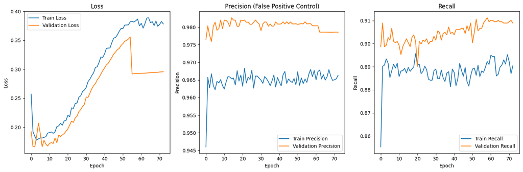

```
2025-05-18 17:49:12,210 - __main__ - INFO - Making predictions with the final model...
148/148 ━━━━━━━━━━━━━━━━━━━━ 0s 3ms/step
2025-05-18 17:49:12,865 - __main__ - INFO - Optimal threshold for 1% FPR: 0.6747
```

```python
class WarmupCosineDecayScheduler(tf.keras.callbacks.Callback):
    """Learning rate scheduler with warmup and cosine decay.

    Implements a learning rate schedule that starts with a warm-up period
    followed by cosine decay to a minimum learning rate.
    """

    def __init__(
        self,
        initial_lr=0.001,
        min_lr=1e-6,
        warmup_epochs=5,
        decay_epochs=95,
    ):
        """Initialize the learning rate scheduler with warmup and cosine decay.

        Args:
            initial_lr (float): Initial learning rate. Default is 0.001.
            min_lr (float): Minimum learning rate after decay. Default is 1e-6.
            warmup_epochs (int): Number of epochs for the warmup phase. Default is 5.
            decay_epochs (int): Number of epochs for the decay phase. Default is 95.
        """
        super(WarmupCosineDecayScheduler, self).__init__()
        self.initial_lr = initial_lr
        self.min_lr = min_lr
        self.warmup_epochs = warmup_epochs
        self.decay_epochs = decay_epochs

    def on_epoch_begin(self, epoch, _=None):
        """Update learning rate at the beginning of each epoch.

        Args:
            epoch (int): Current epoch number
            _ (dict, optional): Unused parameter for compatibility with Keras callback API.
        """
        if epoch < self.warmup_epochs:
            lr = self.initial_lr * ((epoch + 1) / self.warmup_epochs)
        else:
            progress = (epoch - self.warmup_epochs) / self.decay_epochs
            cosine_decay = 0.5 * (1 + np.cos(np.pi * min(1.0, progress)))
            lr = self.min_lr + (self.initial_lr - self.min_lr) * cosine_decay

        if hasattr(self.model.optimizer, "learning_rate"):
            self.model.optimizer.learning_rate.assign(lr)
        else:
            tf.keras.backend.set_value(self.model.optimizer.lr, lr)

        if (epoch + 1) % 5 == 0:
            logger.info(f"Current learning rate: {lr:.6f}")


def find_optimal_threshold_v2(y_true, y_pred_proba, target_fpr=0.01):
    """Find threshold that achieves target false positive rate.

    Args:
        y_true (array-like): Ground truth labels
        y_pred_proba (array-like): Predicted probabilities
        target_fpr (float): Target false positive rate. Default is 0.01.

    Returns:
        float: Optimal threshold value
    """
    threshold_values = np.linspace(0, 1, 1000)
    best_threshold = 0.5
    best_fpr_diff = float("inf")

    for threshold in threshold_values:
        y_pred = np.array(y_pred_proba >= threshold, dtype=np.int32)

        fp_count = np.sum((y_pred == 1) & (y_true == 0))
        tn_count = np.sum((y_pred == 0) & (y_true == 0))

        current_fpr = (
            fp_count / (fp_count + tn_count) if (fp_count + tn_count) > 0 else 0
        )

        fpr_diff = abs(current_fpr - target_fpr)
        if fpr_diff < best_fpr_diff:
            best_fpr_diff = fpr_diff
            best_threshold = threshold

    return best_threshold


def weighted_binary_crossentropy(y_true, y_pred):
    """Custom loss function with adaptive weights for precision-recall balance.

    Args:
        y_true (tensor): Ground truth labels
        y_pred (tensor): Predicted probabilities

    Returns:
        tensor: Weighted binary cross-entropy loss
    """
    y_pred = tf.clip_by_value(y_pred, 1e-7, 1 - 1e-7)

    bce = -(y_true * tf.math.log(y_pred) + (1 - y_true) * tf.math.log(1 - y_pred))

    pt = tf.where(tf.equal(y_true, 1), y_pred, 1 - y_pred)
    focal_weight = tf.pow(1 - pt, 1.5)

    weights = y_true + 3.0 * (1.0 - y_true)

    weighted_bce = weights * focal_weight * bce

    return tf.reduce_mean(weighted_bce)


def build_final_nn_model(
    x_train_data,
    y_train_data,
    x_val_data,
    y_val_data,
    class_weights_dict,
    input_dimension_size,
):
    """Builds and trains the final neural network model with optimized architecture.

    Args:
        x_train_data (array-like): Training features
        y_train_data (array-like): Training labels
        x_val_data (array-like): Validation features
        y_val_data (array-like): Validation labels
        class_weights_dict (dict): Class weights for imbalanced data
        input_dimension_size (int): Input dimension size

    Returns:
        tuple: (trained model, training history)
    """
    inputs = Input(shape=(input_dimension_size,))

    x = Dense(512, activation="relu", kernel_regularizer=l1_l2(l1=1e-6, l2=1e-5))(
        inputs
    )
    x = BatchNormalization()(x)
    x = Dropout(0.3)(x)

    skip = x
    x = Dense(512, activation="relu", kernel_regularizer=l1_l2(l1=1e-6, l2=1e-5))(x)
    x = BatchNormalization()(x)
    x = Dropout(0.25)(x)
    x = Dense(512, activation="relu", kernel_regularizer=l1_l2(l1=1e-6, l2=1e-5))(x)
    x = BatchNormalization()(x)
    x = tf.keras.layers.Add()([x, skip])

    x = Dense(256, activation="relu", kernel_regularizer=l1_l2(l1=1e-6, l2=1e-5))(x)
    x = BatchNormalization()(x)
    x = Dropout(0.2)(x)

    x = Dense(128, activation="relu", kernel_regularizer=l1_l2(l1=1e-6, l2=1e-5))(x)
    x = BatchNormalization()(x)
    x = Dropout(0.15)(x)

    x = Dense(64, activation="relu", kernel_regularizer=l1_l2(l1=1e-6, l2=1e-5))(x)
    x = BatchNormalization()(x)
    x = Dropout(0.1)(x)

    outputs = Dense(1, activation="sigmoid")(x)

    model = tf.keras.Model(inputs, outputs)

    model.compile(
        optimizer=tf.keras.optimizers.Adam(learning_rate=0.001),
        loss=weighted_binary_crossentropy,
        metrics=[
            "accuracy",
            tf.keras.metrics.Precision(name="precision"),
            tf.keras.metrics.Recall(name="recall"),
            tf.keras.metrics.AUC(name="auc"),
        ],
    )

    callbacks_list = [
        tf.keras.callbacks.EarlyStopping(
            monitor="val_auc",
            mode="max",
            patience=25,
            restore_best_weights=True,
            verbose=1,
        ),
        tf.keras.callbacks.ModelCheckpoint(
            filepath="../models/nn_malware_final.keras",
            monitor="val_auc",
            mode="max",
            save_best_only=True,
            verbose=1,
        ),
        WarmupCosineDecayScheduler(
            initial_lr=0.001, min_lr=1e-6, warmup_epochs=5, decay_epochs=95
        ),
        FalsePositiveMonitor(validation_data=(x_val_data, y_val_data), print_freq=5),
    ]

    logger.info("Phase 1: Initial training with balanced objective")
    history1 = model.fit(
        x_train_data,
        y_train_data,
        epochs=75,
        batch_size=64,
        validation_data=(x_val_data, y_val_data),
        class_weight=class_weights_dict,
        callbacks=callbacks_list,
        verbose=1,
    )

    logger.info("Phase 2: Fine-tuning with emphasis on precision")
    model.compile(
        optimizer=tf.keras.optimizers.Adam(learning_rate=1e-5),
        loss=lambda y_true, y_pred: weighted_binary_crossentropy(y_true, y_pred) * 1.5,
        metrics=[
            "accuracy",
            tf.keras.metrics.Precision(name="precision"),
            tf.keras.metrics.Recall(name="recall"),
            tf.keras.metrics.AUC(name="auc"),
        ],
    )

    fine_tuning_callbacks = [
        tf.keras.callbacks.EarlyStopping(
            monitor="val_precision",
            mode="max",
            patience=15,
            restore_best_weights=True,
            verbose=1,
        ),
        tf.keras.callbacks.ModelCheckpoint(
            filepath="../models/nn_malware_final_phase2.keras",
            monitor="val_precision",
            mode="max",
            save_best_only=True,
            verbose=1,
        ),
        FalsePositiveMonitor(validation_data=(x_val_data, y_val_data), print_freq=5),
    ]

    history2 = model.fit(
        x_train_data,
        y_train_data,
        epochs=25,
        batch_size=128,
        validation_data=(x_val_data, y_val_data),
        class_weight={
            0: class_weights_dict[0] * 1.5,
            1: class_weights_dict[1],
        },
        callbacks=fine_tuning_callbacks,
        verbose=1,
    )

    combined_history = {}
    for hist_key in history1.history:
        if hist_key in history2.history:
            combined_history[hist_key] = (
                history1.history[hist_key] + history2.history[hist_key]
            )
        else:
            combined_history[hist_key] = history1.history[hist_key]

    return model, combined_history


x_train_nn, x_val_nn, y_train_nn, y_val_nn = train_test_split(
    x_train_scaled,
    y_train,
    test_size=0.2,
    random_state=RANDOM_SEED,
    stratify=y_train,
)

tf.keras.backend.clear_session()

nn_input_dims = x_train_nn.shape[1]
logger.info(f"Starting model training with input dimension: {nn_input_dims}")

final_model, final_history = build_final_nn_model(
    x_train_nn,
    y_train_nn,
    x_val_nn,
    y_val_nn,
    class_weight_dict,
    nn_input_dims,
)

plt.figure(figsize=(15, 5))

plt.subplot(1, 3, 1)
plt.plot(final_history["loss"], label="Train Loss")
plt.plot(final_history["val_loss"], label="Validation Loss")
plt.title("Loss")
plt.xlabel("Epoch")
plt.ylabel("Loss")
plt.legend()

plt.subplot(1, 3, 2)
plt.plot(final_history["precision"], label="Train Precision")
plt.plot(final_history["val_precision"], label="Validation Precision")
plt.title("Precision (False Positive Control)")
plt.xlabel("Epoch")
plt.ylabel("Precision")
plt.legend()

plt.subplot(1, 3, 3)
plt.plot(final_history["recall"], label="Train Recall")
plt.plot(final_history["val_recall"], label="Validation Recall")
plt.title("Recall")
plt.xlabel("Epoch")
plt.ylabel("Recall")
plt.legend()

plt.tight_layout()
plt.show()

logger.info("Making predictions with the final model...")
y_final_prob = final_model.predict(x_test_scaled).flatten()

final_optimal_threshold = find_optimal_threshold_v2(
    y_test, y_final_prob, target_fpr=0.01
)
logger.info(f"Optimal threshold for 1% FPR: {final_optimal_threshold:.4f}")

y_final_pred = np.array(y_final_prob >= final_optimal_threshold, dtype=np.int32)
```

## Binary Data Representation Analysis

Windows PE files contain both metadata and binary content. While our current model primarily uses metadata and text-derived features, binary data analysis represents a promising area for future enhancement. Several approaches exist for binary data representation in malware detection:

### Binary Data Representation Techniques for Malware Detection

| Technique | Description | Advantages | Challenges |
| --- | --- | --- | --- |
| Byte Histograms | Frequency distribution of byte values (0-255) in the binary | Simple to implement, captures basic statistical properties | Limited semantic understanding, weak against obfuscation |
| N-gram Analysis | Frequency of sequences of n consecutive bytes or opcodes | Captures sequence patterns and common signatures | High dimensionality, sensitive to minor byte changes |
| Entropy Analysis | Measure of randomness in different sections of the binary | Effective at detecting encryption, packing, and obfuscation | Provides limited information by itself, needs context |
| Image-based Representation | Conversion of binary data to grayscale images for visual pattern recognition | Leverages CNN power for pattern recognition, resistant to small changes | Requires significant preprocessing, computationally expensive |
| Opcode Sequences | Extraction and analysis of CPU instruction sequences | Reveals actual program behavior and malicious instructions | Requires disassembly which can be imprecise for obfuscated code |
| Control Flow Graphs | Structural representation of code execution paths | Captures program structure and behavioral patterns | Complex to generate, high computational overhead |
| Transformer-based Models | Tokenization of raw binary data as sequence input to transformer architectures | Captures long-range dependencies and context, handles variable-length inputs, state-of-the-art performance | Computationally expensive, requires large amounts of training data, black-box nature limits interpretability |

While implementation of these techniques is beyond our current scope, incorporating binary analysis features would likely enhance model performance by capturing structural patterns that text and metadata features might miss. Transformer-based approaches are particularly promising, as they can process raw binary files directly through tokenization, treating binary patterns similarly to how language models process text. This represents a valuable direction for future research.

```python
final_results = evaluate_model_performance(
    y_test,
    y_final_pred,
    y_final_prob,
    "Final Neural Network (Optimized for False Positives)",
)

final_comparison = pd.DataFrame(
    [
        {
            "Model": "Dummy Classifier",
            "Accuracy": dummy_results["accuracy"],
            "Precision": dummy_results["precision"],
            "Recall": dummy_results["recall"],
            "F1": dummy_results["f1"],
            "FPR": dummy_results["fpr"],
            "AUC": dummy_results["auc"],
        },
        {
            "Model": "Random Forest",
            "Accuracy": rf_results["accuracy"],
            "Precision": rf_results["precision"],
            "Recall": rf_results["recall"],
            "F1": rf_results["f1"],
            "FPR": rf_results["fpr"],
            "AUC": rf_results["auc"],
        },
        {
            "Model": "XGBoost",
            "Accuracy": xgb_results["accuracy"],
            "Precision": xgb_results["precision"],
            "Recall": xgb_results["recall"],
            "F1": xgb_results["f1"],
            "FPR": xgb_results["fpr"],
            "AUC": xgb_results["auc"],
        },
        {
            "Model": "Neural Network (Default)",
            "Accuracy": nn_results_default["accuracy"],
            "Precision": nn_results_default["precision"],
            "Recall": nn_results_default["recall"],
            "F1": nn_results_default["f1"],
            "FPR": nn_results_default["fpr"],
            "AUC": nn_results_default["auc"],
        },
        {
            "Model": "Final NN (FP-Optimized)",
            "Accuracy": final_results["accuracy"],
            "Precision": final_results["precision"],
            "Recall": final_results["recall"],
            "F1": final_results["f1"],
            "FPR": final_results["fpr"],
            "AUC": final_results["auc"],
        },
    ]
)

display(Markdown("### Final Model Comparison:"))
display(final_comparison)

final_model.save("../models/nn_malware_final_complete.keras")
logger.info("Final model saved in Keras format")
```

```
2025-05-18 17:49:39,844 - windows_malware_classifier.visualization.models_plots - INFO - Final Neural Network (Optimized for False Positives) Performance Metrics:
2025-05-18 17:49:39,846 - windows_malware_classifier.visualization.models_plots - INFO - Accuracy: 0.8718
2025-05-18 17:49:39,848 - windows_malware_classifier.visualization.models_plots - INFO - Precision: 0.9924 (indicates false positive control)
2025-05-18 17:49:39,850 - windows_malware_classifier.visualization.models_plots - INFO - Recall: 0.7988
2025-05-18 17:49:39,852 - windows_malware_classifier.visualization.models_plots - INFO - F1 Score: 0.8851
2025-05-18 17:49:39,853 - windows_malware_classifier.visualization.models_plots - INFO - False Positive Rate: 0.0100
2025-05-18 17:49:39,854 - windows_malware_classifier.visualization.models_plots - INFO - True Positive Rate: 0.7988
2025-05-18 17:49:39,854 - windows_malware_classifier.visualization.models_plots - INFO - AUC: 0.9803
```

Final Model Comparison:

|  | Model | Accuracy | Precision | Recall | F1 | FPR | AUC |
| --- | --- | --- | --- | --- | --- | --- | --- |
| 0 | Dummy Classifier | 0.524081 | 0.615306 | 0.615096 | 0.615201 | 0.623477 | 0.495809 |
| 1 | Random Forest | 0.965146 | 0.977862 | 0.965505 | 0.971645 | 0.035437 | 0.995438 |
| 2 | XGBoost | 0.979299 | 0.984921 | 0.981557 | 0.983236 | 0.024363 | 0.997825 |
| 3 | Neural Network (Default) | 0.932193 | 0.974863 | 0.913934 | 0.943416 | 0.038206 | 0.982353 |
| 4 | Final NN (FP-Optimized) | 0.871779 | 0.992363 | 0.798839 | 0.885147 | 0.009967 | 0.980350 |

```
2025-05-18 17:49:40,115 - __main__ - INFO - Final model saved in Keras format
```

## Conclusion and Recommendations

This notebook demonstrated the development of a machine learning model for Windows PE malware detection, with a strong focus on minimizing false positives.

**Recommendations**

- **Model Selection:** Given the results, consider using the **XGBoost** model as your primary detection model, due to its superior performance in this specific experiment.
- **Production Deployment:**
  - Deploy the chosen model (XGBoost or the optimized NN).
  - Set the classification threshold based on your organization's risk tolerance. A lower FPR (e.g., 0.01) is generally preferred to minimize user disruption, even if it slightly reduces the true positive rate.
  - Continuously monitor model performance in a production setting, paying close attention to the FPR.
- **Further Feature Engineering:**
  - Continue to explore and refine text-based features, including those that might indicate string obfuscation.
  - Investigate incorporating binary-level features, such as byte n-grams, section-specific entropy, and potentially opcode sequences (if disassembly is feasible). This is a promising area for future improvement.
  - Explore more interaction features between different feature types.
- **Model Improvement:**
  - Consider using outputs from the neural network as features within the XGBoost model.
  - Periodically retrain the model with new data to maintain accuracy and adapt to evolving malware trends.
  - Experiment with more advanced neural network architectures, potentially including those designed for sequence data (if incorporating binary/opcode features).
- **Operational Considerations:**
  - Develop strategies to get labelled data continuously.

**Limitations and Future Work**

- **Dataset:** The current analysis is limited to a specific dataset of Windows PE files. Performance may vary on different datasets or with new types of malware.
- **Static Analysis:** This notebook focused on static analysis of PE files. Incorporating dynamic analysis (e.g., sandbox execution) could significantly enhance detection capabilities, particularly against heavily obfuscated malware.
- **Adversarial Attacks:** Future work should investigate the robustness of the model against adversarial attacks, where malware authors intentionally try to evade detection. Techniques like adversarial training could be explored.
- **Real-time Performance:** While not directly addressed here, model inference speed is crucial for real-time detection. Optimization for speed may be necessary for deployment in high-volume environments.

By focusing on a single, well-optimized model and carefully managing the classification threshold, we can build a robust and practical malware detection system that minimizes false positives while maintaining high accuracy. Continuous monitoring, feature engineering, and model refinement are crucial for long-term effectiveness.

```python
final_model.save("../models/final_malware_detector.keras")

model_summary = {
    "Model": "Neural Network (Optimized for False Positives)",
    "Input Features": x_train_scaled.shape[1],
    "Hidden Layers": 4,
    "Accuracy": final_results["accuracy"],
    "Precision": final_results["precision"],
    "Recall": final_results["recall"],
    "F1 Score": final_results["f1"],
    "AUC": final_results["auc"],
    "False Positive Rate": final_results["fpr"],
    "Classification Threshold": final_optimal_threshold,
    "Random Seed": RANDOM_SEED,
}

with open("../models/model_summary.txt", "w") as summary_file:
    for key, value in model_summary.items():
        summary_file.write(f"{key}: {value}\n")

logger.info("Model artifacts saved to ../models/ directory")
```

```
2025-05-18 17:50:22,545 - __main__ - INFO - Model artifacts saved to ../models/ directory
```